# Accounting for uncertainty in simulating greenhouse gas emissions from dairy cattle in Kenya

Eike Luedeling, Cory Whitney, Andreas Wilkes, Todd Rosenstock

# 1 Setting up

Note that the code for all operations is hidden, so that it doesn’t clutter the document. You can make it appear by clicking the code button on the right.

We first need to install and load all required packages.

```r
devtools::install_github("CWWhitney/uncertainty")
library(DiagrammeR)
library(decisionSupport)
library(ggplot2)
library(kableExtra)
library(magrittr)
library(plyr)
library(rmarkdown)
library(uncertainty)
library(chillR)
library(raster)
library(reshape2)
library(patchwork)
library(DT)
```

## 1.1 Load emission calculation function

Greenhouse gas emissions from livestock are calculated according to Chapter 10 of the *2006 IPCC Guidelines for National Greenhouse Gas Inventories* (Dong et al. 2006) (Volume 4 - Agriculture, Forestry and Other Land Use). The document can be found on [the IPCC website](https://www.ipcc-nggip.iges.or.jp/public/2006gl/pdf/4_Volume4/V4_10_Ch10_Livestock.pdf). The chapter is part of the book *Good Practice Guidance and Uncertainty Management in National Greenhouse Gas Inventories* (IPCC 2021), also on the [the IPCC website](https://www.ipcc-nggip.iges.or.jp/public/gp/english/). Many variables are based on the work done in *Variation in the carbon footprint of milk production on smallholder dairy farms in central Kenya* (Wilkes et al. 2020) and in *Methods and guidance to support MRV of livestock emissions* (Wilkes et al. 2019). We also draw on recommendations provided in Chapter 10 of Volume 4 of the *2019 Refinement to the 2006 IPCC Guidelines for National Greenhouse Gas Inventories* (Dong et al. 2019), which is also accessible via [the IPCC website](https://www.ipcc-nggip.iges.or.jp/public/2019rf/vol4.html).

The equations provided in these documents, in particular in the 2006 guideline document (Dong et al. 2006) were converted into an R function called `ghg_emissions`, which is defined here (hit the `Code` button on the right).

```r
# Generate the GHG emissions function
ghg_emissions<-function(x, varnames){

  # Enteric fermentation emissions ($CH_4$)

  # The main source of all this is Chapter 10 of the *2006 IPCC Guidelines
  # for National Greenhouse Gas Inventories*
  # (Volume 4 - Agriculture, Forestry and Other Land Use).
  # The document can be found on the IPCC web
  # https://www.ipcc-nggip.iges.or.jp/public/2006gl/pdf/4_Volume4/V4_10_Ch10_Livestock.pdf

  # We start with the net energy for maintenance (NE_m; in MJ/day)
  # This includes a maintenance coefficient,
  # for which different values are recommended depending on animal type

  # The following animal types were used in the example:

  # animal type 1 - 'intact' grown-up males >=36 months
  # animal type 2 - castrated grown-up males >=36 months
  # animal type 3 - males 12-36 months
  # animal type 4 - lactating cows
  # animal type 5 - lactating cows
  # animal type 6 - lactating cows
  # animal type 7 - weaned young females <= 12 months
  # animal type 8 - weaned young males <= 12 months
  # animal type 9 - females 12-36 months
  # animal type 10 - pre-weaned female calves (<12 months)
  # animal type 11 - pre-weaned male calves (<12 months)
  # animal type 12 - first-time pregnant cows

  # animal types 4, 5 and 6 are all lactating cows -
  # important to note here that the original data table
  # appears to have worked with the actual number of months
  # that cows were pregnant. This resulted in a weighted mean
  # of the various maintenance coefficients.
  # We're not sure where we could get such data.
  # In the original dataset, types 4, 5 and 6
  # referred to different pregnancy/lactation states,
  # but it doesn't seem like this scheme was rigorously followed.

  # We make placeholder vectors to collect emissions data
  # for all animal types
  mm_N2O_CO2eq<-c()
  mm_CH4_CO2eq<-c()
  enteric_CH4_CO2eq<-c()
  total_milk<-c()

  # Now we start a long loop,
  # where emissions are calculated for each animal type

  for (animal_type in 1:12)
  {
    # define C and Cfi based on sex (Page 10.17, below Equation 10.6)
    if(animal_type %in% c(1,3,8,11)) growth_coefficient_C<-C_intact_males # males (1.2)
    if(animal_type %in% c(2)) growth_coefficient_C<-C_castrates # castrates (1.0)
    if(animal_type %in% c(4,5,6,7,9,10,12)) growth_coefficient_C<-C_females # females (0.8)

    if(animal_type %in% c(4,5,6)) Cfi<-maintenance_coefficient_Cfi_lact_cow # lactating cows (0.386)
    if(animal_type %in% c(1)) Cfi<-maintenance_coefficient_Cfi_bulls # bulls (0.37)
    if(animal_type %in% c(2,3,7,8,9,10,11,12)) Cfi<-maintenance_coefficient_Cfi_other # others (0.322)

    # define mature body weight (assuming this needs to be disaggregated by sex, for Eqation 10.6)
    if(animal_type %in% c(1,2,3,8,11)) mature_weight_MW<-mature_weight_MW_male
    if(animal_type %in% c(4,5,6,7,9,10,12)) mature_weight_MW<-mature_weight_MW_female

    # define milk yield
    if(animal_type %in% c(1,2,3,7,8,9,10,11,12)) milk_yield<-0
    if(animal_type %in% c(4,5,6)) milk_yield<-eval(parse(text=paste0("milk_yield_",animal_type)))

    #define pregnancy coefficient (full Cp for first-time pregnant, lower for later in most cases)
    if(animal_type==12) Cp<-Cp_0
    if(animal_type==4) Cp<-Cp_0*Cp_rate_4
    if(animal_type==5) Cp<-Cp_0*Cp_rate_5
    if(animal_type==6) Cp<-Cp_0*Cp_rate_6
    if(animal_type %in% c(1,2,3,7,8,9,10,11)) Cp<-0

    N_animal_type<-eval(parse(text=paste0("N_animal_type_",animal_type)))

    # define activity coefficient Ca (Table 10.5)
    # Stall 0.00 - Animals are confined to a small area
    #     (i.e., tethered, pen, barn) with the result that they expend
    #     very little or no energy to acquire feed.
    # Pasture 0.17 - Animals are confined in areas with sufficient forage
    #     requiring modest energy expense to acquire feed.
    # Grazing large areas 0.36 - Animals graze in open range land
    #     or hilly terrain and expend significant energy to acquire feed.


    if(feeding_system==1) C_activity<-Ca_stall # Stall (0.0)
    if(feeding_system==2) C_activity<-Ca_pasture # Stall (0.17)
    if(feeding_system==3) C_activity<-Ca_large_grazing # Stall (0.36)

    # Mean live weight (kg) of animals surely varies by animal type,
    # so we need separate estimates for them
    live_weight_LW<-eval(parse(text=paste0("live_weight_LW_",animal_type)))

    # Mean weight gain of animal type (kg/day)
    weight_gain_WG<-eval(parse(text=paste0("weight_gain_WG_",animal_type)))

    # Calculate the Net Energy for Maintenance (NE_m) (MJ/day) (Equation 10.3)
    NE_m<-Cfi*(live_weight_LW^0.75)

    # Calculate the Net Energy for Activity (NE_activity) (MJ/day) (Equation 10.4)
    NE_activity<-C_activity*NE_m

    #Net energy for growth (NE_growth) (MJ/day) (Equation 10.6)
    NE_growth<-22.02*
      ((live_weight_LW/(growth_coefficient_C*mature_weight_MW))^0.75)*
      (weight_gain_WG^1.097)

    # Net energy for lactation
    NE_lactation<-milk_yield*(1.47+0.40*milk_fat)

    #Energy need during pregnancy (Equation 10.13)
    NE_pregnancy<-Cp*NE_m

    # Ratio of net energy available in a diet for maintenance
    # to digestible energy consumed (Equation 10.14)
    REM<-1.123-(4.092/1000*DE_perc)+(1.126/100000*DE_perc^2)-(25.4/DE_perc)

    # Ratio of net energy available for growth in a diet
    # to digestible energy consumed (Equation 10.15)
    REG<-1.164-(5.160/1000*DE_perc)+(1.308/100000*DE_perc^2)-(37.4/DE_perc)

    # Gross Energy (GE) MJ/day
    NE_work<-0 # work animals aren't covered here, so we set this to zero
    GE<-(((NE_m+NE_activity+NE_lactation+NE_work+NE_pregnancy)/REM)+
           (NE_growth/REG))/(DE_perc/100)

    # CH4 emission factors for enteric fermentation from a livestock category
    # (Equation 10.21)
    enteric_CH4<-(GE*Y_m*365)/55.65 # kg CH4 per animal per year

    # Compute the CO2-equivalent of methane emissions for enteric methane
    # This converts methane emissions to their Global Warming Potential
    # (CO2-equivalent of CH4 is 25)
    enteric_CH4_CO2eq[animal_type]<-N_animal_type*enteric_CH4*25

    # Manure management methane ($CH_4$) and nitrous oxide ($N_2O$)
    # daily volatile solid excreted (Equation 10.24)

    volsol<-(GE*
               (1-(DE_perc/100))+
               (urinary_energy*GE))*
      ((1-ash_content)/18.45)

    # The maximum methane emission from manure (Bo) depends on the animal type.
    # In the input table, we treat these as constants for each animal type.
    # The following line assigns the corresponding Bo value

    Bo<-eval(parse(text=paste0("Bo_animaltype_",animal_type)))

    # CH4 emission factor from manure management (Equation 10.23)
    mm_ch4<-(volsol*365)*
      (Bo*0.67*
         ((mms_pasture*MCFpasture)+
            (mms_spread*MCFspread)+
            (mms_drylot*MCFdrylot)+
            (mms_solidstore*MCFsolidstore)+
            (mms_composted*MCFcomposted)+
            (mms_liquid*MCFliquid)+
            (mms_biogas*MCFbiogas)+
            (mms_burn*MCFburn)+
          # the original code was lacking the 'sold' fraction -
          # we added this for completeness
          (mms_sold*MCFsold)))

    # Estimate CO2eq for manure methane
    mm_CH4_CO2eq[animal_type]<-N_animal_type*mm_ch4*25

    # Calculate Nitrous oxide emissions from manure and urine on pasture

    # estimate N intake (kg/animal/day) (Equation 10.32)
    N_intake<-(GE/18.45)*((perc_crude_protein_diet/100)/6.25)

    # estimate N retention (kg/animal/day) (Equation 10.33)

    if(weight_gain_WG==0)
      N_retention <- ((milk_yield*(1.9+0.4*milk_fat)/100)/6.38)

    if(!weight_gain_WG==0)
      N_retention<-((milk_yield*(1.9+0.4*milk_fat)/100)/6.38)+
      ((weight_gain_WG*(268-(7.03*NE_growth/weight_gain_WG)))/(1000*6.25))

    # estimate N excretion
    # (kg N/animal/yr) (Equation 10.31)
    N_excretion<-N_intake*(1-N_retention)*365

    # Direct nitrous oxide emissions
    # (kg N2O/animal/yr) (Eq 10.25 from IPCC guidelines)
    mm_direct_n2o<-N_excretion*((mms_pasture*mndec_pasture)+
                                  (mms_spread*mndec_spread)+
                                  (mms_drylot*mndec_drylot)+
                                  (mms_solidstore*mndec_solidstore)+
                                  (mms_composted*mndec_composted)+
                                  (mms_liquid*mndec_liquid)+
                                  (mms_biogas*mndec_biogas)+
                                  (mms_burn*mndec_burn)+
                                  (mms_sold*mndec_sold))*(44/28)

    # N losses from volatilization
    # (kg N/animal/yr) (Eq 10.26 from IPCC guidelines)
    mm_vol_n<-N_excretion*((mms_pasture*mnvc_pasture)+
                             (mms_spread*mnvc_spread)+
                             (mms_drylot*mnvc_drylot)+
                             (mms_solidstore*mnvc_solidstore)+
                             (mms_composted*mnvc_composted)+
                             (mms_liquid*mnvc_liquid)+
                             (mms_biogas*mnvc_biogas)+
                             (mms_burn*mnvc_burn)+
                             (mms_sold*mnvc_sold))

    # indirect N2O emissions due to volatilization of N from manure management
    # (kg N2O/animal/year) (Equation 10.27)
    mm_vol_n2o<-mm_vol_n*EF4*(44/28)

    # Nitrous oxide (N2O) from leaching (kg N/animal/year) (equation 10.28)
    mm_leach_n<-N_excretion*((mms_pasture*frac_leach_pasture)+
                               (mms_spread*frac_leach_spread)+
                               (mms_drylot*frac_leach_drylot)+
                               (mms_solidstore*frac_leach_solidstore)+
                               (mms_composted*frac_leach_composted)+
                               (mms_liquid*frac_leach_liquid)+
                               (mms_biogas*frac_leach_biogas)+
                               (mms_burn*frac_leach_burn)+
                               (mms_sold*frac_leach_sold))

    # indirect N2O emissions due to leaching of N from manure management
    # (kg N2O/animal/year) (Equation 10.29)
    mm_leach_n2o<-mm_leach_n*EF5*(44/28)

    # CW EL Comment ####
    # # comment: we removed this, it was probably wrong,
    # since leached nitrogen doesn't emit (much) nitrous oxide
    #mm_leach_n2o<-n_excretion*((mms_pasture*0.3)+(mms_spread*0.3)+(mms_drylot*0.3)+(mms_solidstore*0.3)+
    #              (mms_composted*0.3)+(mms_liquid*0.3)+(mms_biogas*0)+(mms_burn*0))*0.0075*(44/28)

    # Estimate CO2eq for manure nitrous
    mm_N2O_CO2eq[animal_type]<-N_animal_type*(mm_direct_n2o+mm_vol_n2o+mm_leach_n2o)*298 # (298 is the CO2-equivalent of N2O)

    total_milk[animal_type]<-N_animal_type*milk_yield*365

  }

  # Emissions from feed production and transport.

  feed_CO2<-feed_prod_CO2+feed_trans_CO2

  # Total emissions

  on_farm<-sum(enteric_CH4_CO2eq+mm_CH4_CO2eq+mm_N2O_CO2eq)+feed_CO2

  total_animals<-sum(sapply(1:12,function(x) eval(parse(text=paste0("N_animal_type_",x)))))

  return(list(enteric_CH4=enteric_CH4,
              milk_yield=sum(total_milk),
              enteric_CH4_CO2eq=sum(enteric_CH4_CO2eq),
              mm_CH4_CO2eq=sum(mm_CH4_CO2eq),
              mm_N2O_CO2eq=sum(mm_N2O_CO2eq),
              feed_CO2=feed_CO2,
              on_farm=on_farm,
              pc_enteric_CH4=enteric_CH4/total_animals,
              pc_milk_yield=sum(total_milk)/total_animals,
              pc_enteric_CH4_CO2eq=sum(enteric_CH4_CO2eq)/total_animals,
              pc_mm_CH4_CO2eq=sum(mm_CH4_CO2eq)/total_animals,
              pc_mm_N2O_CO2eq=sum(mm_N2O_CO2eq)/total_animals,
              pc_feed_CO2=feed_CO2/total_animals,
              pc_on_farm=on_farm/total_animals


              ))
}
```

This equation takes a wide range of inputs. Many of these are usually not known precisely, yet the classic IPCC equation does not account for potential errors and uncertainties. Here, we express this uncertainty by defining distributions for each variable. The following table (Table S1) shows all the variables, as well as examples of distributions that may describe their quantities. Distributions are defined according to the distribution shape, as well as upper and lower bounds of 90% confidence intervals. We use the following distribution shapes:

- const - constants (upper and lower bounds are the same)
- posnorm - positive normal distribution; this is a normal distribution that is truncated at 0.

*Table S1* *Model input parameters for the Monte Carlo simulation, including the variable names used in the greenhouse gas emissions equation, a descriptive label, lower and upper bounds of 90% confidence intervals for the values, and the shape of the probability distribution that is used to describe the data. The IPCC_default column shows values used for producing (spuriously) the precise scenario. Note that some values are overwritten when producing farm-scale scenarios. Data can be downloaded in csv or Excel format or copied to the clipboard by pressing the respective buttons.*

```r
input_parameters<-read.csv("data/livestock_ghg_input_table.csv")[,c(7,2,3,5,6,8)]
input_parameters<-input_parameters[which(!is.na(input_parameters$lower)),]

input_parameters %>%
  datatable(extensions = 'Buttons',
            options = list(dom = 'Blfrtip',
                           buttons = c('copy', 'csv', 'excel'),
                           lengthMenu = list(c(10,25,50,-1),
                                             c(10,25,50,"All")),
                           list(scrollX = "300px"),
                           autoWidth = TRUE),
            rownames=FALSE)
```

| variable | label | lower | upper | distribution | IPCC_default |
| --- | --- | --- | --- | --- | --- |
| feeding_system | Feeding system (1 Stall - 2 Pasture - 3 Grazing large area) | 1 | 1 | const |  |
| Ca_stall | Activity coefficient Ca - Stall feeding | 0 | 0 | const | 0 |
| Ca_pasture | Activity coefficient Ca -Pasture feeding | 0.1445 | 0.1955 | posnorm | 0.17 |
| Ca_large_grazing | Activity coefficient Ca - Grazing large area | 0.306 | 0.414 | posnorm | 0.36 |
| N_animal_type_1 | Number of 'intact' mature bulls (&gt;36 months) (animal type 1) | 5 | 5 | const |  |
| N_animal_type_2 | Number of mature castrates (&gt;36 months) (animal type 2) | 2 | 2 | const |  |
| N_animal_type_3 | Number of males 12-36 months (animal type 3) | 4 | 4 | const |  |
| N_animal_type_4 | Number of lactating cows (animal type 4) | 5 | 5 | const |  |
| N_animal_type_5 | Number of lactating cows (animal type 5) | 3 | 3 | const |  |
| N_animal_type_6 | Number of lactating cows (animal type 6) | 2 | 2 | const |  |

[output cut: 112 more lines]

The decisionSupport package (Luedeling et al. 2022), which we use to run the simulations, also accommodates other distribution types, but we did not consider these appropriate here. The positive normal distribution (and other distributions such as normal or lognormal distributions) are defined based on the 5% and 95% quantiles. Note that it isn’t always possible to fit a positive normal distribution based on such specifications, especially if the 5% quantile is set so close to zero that the remaining 5% of the data do not **fit** in the space between zero and the lower bound. In such cases, decisionSupport (Luedeling et al. 2022) returns a warning message, but it still does its best to generate the requested distribution. It is worth being on the lookout for the respective warning messages and try to adjust the bounds of the distribution to **possible** values.

# 2 Monte Carlo simulation

With the model equation and the input table defined above, we can run a Monte Carlo simulation that returns a probability distribution for the greenhouse gas emissions resulting from the particular herd that is specified in the input table. We use the functions provided by the decisionSupport package (Luedeling et al. 2022) in the R programming language (R Core Team 2021).

```r
input_table <- "data/livestock_ghg_input_table.csv"
GHG_emissions<-mcSimulation(estimate=estimate_read_csv(input_table),
                            model_function=ghg_emissions,
                            numberOfModelRuns=1000,
                            functionSyntax="plainNames")
```

## 2.1 Running a Monte Carlo simulation with scenarios

The `mcSimulation` function takes random draws for each of the input variables from the distributions specified in the input table. The distributions that are used are the same for every run of the Monte Carlo simulation. This may be desirable in homogeneous populations where all combinations of random values are plausible, but it often misses the mark where populations are composed of particular member types with specific characteristics. To account for populations that are heterogeneous, which is the case for livestock-keeping households in Kenya, we use the `scenario_mc` function, which allows specifying particular subgroups. Defining such scenarios can be desirable when it’s necessary to simulate outcomes for particular farm types, climate scenarios etc. To do this, we would normally have to define separate input tables and run separate simulations. This is quite inconvenient. Here, we use a function that can do this job automatically.

The `scenario_mc` function in the `decisionSupport` package (Luedeling et al. 2022) consists of a wrapper around the `mcSimulation` function. The function can modify the input table according to a scenario file we provide. This file contains information on which variables should be modified for each scenario and how many model runs should be included in the simulation. The function call is essentially the same as for the `mcSimulation` function, but with an additional `scenarios` option which imports the contents of a .csv file.

The .csv file for the `scenarios` option specifies variables that should be modified for each of the scenarios, as well as the number of model runs for it. Each column beyond the first two columns in the file contains information for a particular scenario. This is restricted to the parameters that *should be changed* for this scenario (all others don’t have to be included).

Each row in this table indicates which value from the input table should be modified, so the string in the first column has to correspond to a variable name in the input table (additionally, the number of runs per scenario can be specified by a row with ‘Runs’ in the ‘Variable’ column, but this was not done here). The second column indicates which values should be changed, with options being “lower”, “upper”, “distribution” and “both”. If “both” is selected, both the lower and upper bounds are modified (this should only be done for variables with a constant distribution, since the replacement will be for both the upper and lower bound).

We define subgroups based on the populations of households described by a household survey in Kenya (Wilkes et al. 2020, 2019). Each of the farms encountered in this survey was converted into one scenario, for which Monte Carlo simulation is then used to produce multiple replicates.

## 2.2 Household-based scenarios

The information for the household is extracted from a spreadsheet that contains all the survey responses (Wilkes et al. 2020, 2019).

### 2.2.1 Probabilistic scenarios

Extracting all relevant information from the survey results spreadsheet is a slightly complex task, which is accomplished by the following code. The code includes specification of lower and upper bounds of probability distributions for most of the variables. We keep the herd composition constant, but all variables that in all likelihood weren’t determined with high precision and accuracy are equipped with such uncertainty estimates. Estimates of the uncertainty for model input variables were extracted from the IPCC documents, or, if no such indications were available, based on our expert judgement.

```r
# import the data from the survey and ensure that the .csv encoding can be read by R

Kenyaherds<-read.table("data/Kenya_baseline_individual_cow_wNotes.csv", sep = ",",
                       fileEncoding = "UTF-8-BOM", header=TRUE)

# count the number of animals for each type

animals<-table(Kenyaherds[,c("QQNO","animal_type")])

variables_to_update_const<-c(paste0("N_animal_type_",1:12),
                             "feeding_system")

scenarios<-data.frame(Variable=variables_to_update_const,param="both")

variables_to_update_posnorm<-c(paste0("milk_yield_",4:6),
                             paste0("Cp_rate_",4:6),
                             "feed_prod_CO2",
                             "feed_trans_CO2",
                             paste0("live_weight_LW_",1:12),
                             paste0("weight_gain_WG_",1:12),
                             "DE_perc",
                             "perc_crude_protein_diet")

scenarios<-rbind(scenarios,data.frame(Variable=rep(variables_to_update_posnorm,each=3),param=c("lower","upper","distribution")))

for(i in 1:nrow(animals))
  {coln<-paste0("Farm_",row.names(animals)[i])
   scenarios[,coln]<-NA
     scenarios[which(scenarios$Variable %in% paste0("N_animal_type_",1:12)),coln]<-animals[i,]
}

# for some animal-scale variables (e.g. milk yield), we need averages per farm

### error estimates for variables
milk_yield_error<-0.275 # Migose et al. (2020, https://www.sciencedirect.com/science/article/abs/pii/S1871141319307371 )
feed_trans_error<-0.25 # Vellinga et al (2013, https://edepot.wur.nl/254098)
feed_prod_error<-0.25 # Vellinga et al (2013, https://edepot.wur.nl/254098)
live_weight_error<-0.145 # Goopy et al. (2018, https://www.publish.csiro.au/an/an16577 )
weight_gain_error<-0.145 # Goopy et al. (2018, https://www.publish.csiro.au/an/an16577 )
digestible_energy_error<-0.1
crude_protein_error<-0.1

# farm-scale variables

Farms<-unique(Kenyaherds$QQNO)

for (f in Farms)
  {coln<-paste0("Farm_",f)
  # update feeding system
  scenarios[which(scenarios$Variable == "feeding_system"),coln]<-
     median(Kenyaherds[which(Kenyaherds$QQNO==f),"system"])

  # update digestible energy (mean for all animals for now) (with error)
  scenarios[which(scenarios$Variable == "DE_perc"),coln][1:2]<-
     mean(Kenyaherds[which(Kenyaherds$QQNO==f),"dig_energy"])*
                           c(1-digestible_energy_error,1+digestible_energy_error)

  # update crude protein (mean for all animals for now) (with error)
  scenarios[which(scenarios$Variable == "perc_crude_protein_diet"),coln][1:2]<-
     mean(Kenyaherds[which(Kenyaherds$QQNO==f),"CP."])*
                           c(1-crude_protein_error,1+crude_protein_error)

  # update feed production CO2 (with error)
   scenarios[which(scenarios$Variable == "feed_prod_CO2"),coln][1:2]<-
     sum(Kenyaherds[which(Kenyaherds$QQNO==f),"feed_kgCO2"])*
                           c(1-feed_prod_error,1+feed_prod_error)

  # update feed transport CO2 (with error)
   scenarios[which(scenarios$Variable == "feed_trans_CO2"),coln][1:2]<-
     sum(Kenyaherds[which(Kenyaherds$QQNO==f),"feed.transport_kgCO2"])*
                           c(1-feed_trans_error,1+feed_trans_error)

   # update milk yield for each cow type (animal type 4-6) (with error)
   for(typ in 4:6)
     if(sum(Kenyaherds$QQNO==f&Kenyaherds$animal_type==typ)>0)
       {scenarios[which(scenarios$Variable==paste0("milk_yield_",typ)),coln][1:2]<-
         mean(Kenyaherds[which(Kenyaherds$QQNO==f&Kenyaherds$animal_type==typ),
                         "milk_yield"])*c(1-milk_yield_error,1+milk_yield_error)
       scenarios[which(scenarios$Variable==paste0("CP_rate_",typ)),coln][1:2]<-
         mean(Kenyaherds[which(Kenyaherds$QQNO==f&Kenyaherds$animal_type==typ),
                         "Cp"]/0.1) *c(1,1)

     }
  # update live weight and weight gain for each animal type (with error)
   for(typ in 1:12)
     if(sum(Kenyaherds$QQNO==f&Kenyaherds$animal_type==typ)>0)
       {scenarios[which(scenarios$Variable==paste0("live_weight_LW_",typ)),coln][1:2]<-
         mean(Kenyaherds[which(Kenyaherds$QQNO==f&Kenyaherds$animal_type==typ),
                         "live_weight_LW"])*c(1-live_weight_error,1+live_weight_error)
       scenarios[which(scenarios$Variable==paste0("weight_gain_WG_",typ)),coln][1:2]<-
         mean(Kenyaherds[which(Kenyaherds$QQNO==f&Kenyaherds$animal_type==typ),
                         "weight_gain_WG"])*c(1-weight_gain_error,1+weight_gain_error)
     }

   for(varia in variables_to_update_posnorm)
   if(sum(is.na(scenarios[which(scenarios$Variable==varia),coln][1:2]))==0)
     if(!equals(scenarios[which(scenarios$Variable==varia),coln][1],
               scenarios[which(scenarios$Variable==varia),coln][2]))
        scenarios[which(scenarios$Variable==varia&
                   scenarios$param=="distribution"),coln]<-"posnorm" else
            scenarios[which(scenarios$Variable==varia&
                   scenarios$param=="distribution"),coln]<-"const"

   }

write.csv(scenarios,"data/farm_scenarios.csv",row.names = FALSE)
```

*Table S2* *Model input parameters for producing farm-scale scenarios for the Monte Carlo simulation, listing all variables that need to be updated. Data can be downloaded in csv or Excel format or copied to the clipboard by pressing the respective buttons.*

```r
scenario_parameters<-read.csv("data/farm_scenarios.csv")

scenario_parameters %>%
  datatable(extensions = 'Buttons',
            options = list(dom = 'Blfrtip',
                           buttons = c('copy', 'csv', 'excel'),
                           lengthMenu = list(c(10,25,50,-1),
                                             c(10,25,50,"All")),
                           list(scrollX = "300px")),
            rownames=FALSE)
```

| Variable | param | Farm_1 | Farm_2 | Farm_3 | Farm_4 | Farm_5 | Farm_6 | Farm_7 | Farm_8 | Farm_9 | Farm_10 | Farm_11 | Farm_12 | Farm_13 | Farm_14 | Farm_15 | Farm_16 | Farm_18 | Farm_19 | Farm_20 | Farm_21 | Farm_22 | Farm_23 | Farm_24 | Farm_25 | Farm_26 | Farm_27 | Farm_28 | Farm_29 | … |
| --- | --- | --- | --- | --- | --- | --- | --- | --- | --- | --- | --- | --- | --- | --- | --- | --- | --- | --- | --- | --- | --- | --- | --- | --- | --- | --- | --- | --- | --- | --- |
| N_animal_type_1 | both | 0 | 1 | 1 | 0 | 0 | 0 | 0 | 0 | 0 | 1 | 0 | 0 | 0 | 0 | 0 | 0 | 0 | 0 | 0 | 0 | 0 | 0 | 0 | 0 | 0 | 0 | 2 | 0 | … |
| N_animal_type_2 | both | 0 | 0 | 0 | 0 | 0 | 0 | 0 | 0 | 0 | 0 | 0 | 0 | 0 | 0 | 0 | 0 | 0 | 0 | 0 | 0 | 0 | 0 | 0 | 0 | 0 | 0 | 0 | 0 | … |
| N_animal_type_3 | both | 0 | 0 | 0 | 0 | 0 | 0 | 0 | 0 | 0 | 0 | 0 | 0 | 0 | 0 | 0 | 0 | 2 | 0 | 0 | 0 | 0 | 0 | 0 | 0 | 0 | 0 | 0 | 0 | … |
| N_animal_type_4 | both | 0 | 1 | 0 | 0 | 0 | 0 | 1 | 0 | 0 | 0 | 0 | 0 | 1 | 1 | 0 | 0 | 0 | 0 | 1 | 3 | 0 | 0 | 0 | 0 | 0 | 0 | 2 | 0 | … |
| N_animal_type_5 | both | 0 | 0 | 2 | 1 | 2 | 1 | 1 | 1 | 2 | 1 | 2 | 1 | 0 | 2 | 1 | 2 | 2 | 1 | 3 | 1 | 2 | 1 | 0 | 1 | 0 | 1 | 1 | 2 | … |
| N_animal_type_6 | both | 2 | 0 | 0 | 0 | 1 | 1 | 0 | 0 | 0 | 1 | 3 | 0 | 0 | 1 | 1 | 1 | 1 | 1 | 3 | 0 | 2 | 0 | 1 | 0 | 1 | 0 | 0 | 0 | … |
| N_animal_type_7 | both | 1 | 0 | 0 | 0 | 1 | 0 | 0 | 0 | 0 | 0 | 0 | 0 | 0 | 0 | 0 | 0 | 0 | 1 | 0 | 0 | 2 | 0 | 0 | 0 | 0 | 0 | 0 | 0 | … |
| N_animal_type_8 | both | 0 | 0 | 0 | 0 | 1 | 0 | 0 | 0 | 1 | 0 | 0 | 0 | 0 | 0 | 0 | 0 | 0 | 0 | 0 | 0 | 0 | 0 | 0 | 0 | 0 | 0 | 0 | 0 | … |
| N_animal_type_9 | both | 0 | 1 | 0 | 0 | 1 | 1 | 1 | 1 | 0 | 1 | 0 | 1 | 0 | 2 | 2 | 0 | 0 | 2 | 1 | 1 | 1 | 1 | 1 | 0 | 1 | 2 | 1 | 0 | … |
| N_animal_type_10 | both | 0 | 0 | 0 | 1 | 0 | 0 | 0 | 0 | 0 | 0 | 0 | 0 | 0 | 0 | 0 | 0 | 0 | 0 | 1 | 0 | 0 | 0 | 0 | 0 | 0 | 0 | 0 | 1 | … |

[output cut: 105 more lines]

The first few rows in this table adjust the herd composition parameters, so that the scenario herd corresponds to the herd of the specific household. Other parameters including the milk yield per cow are also adjusted.

### 2.2.2 Precise scenarios

We also make precise scenarios that contain only the exact values that were observed in the survey. This is needed for illustrating the impact of accounting for uncertainty later. For these scenarios, we follow the commonly used practice of applying default values recommended by the various IPCC documents mentioned above (Dong et al. 2006, 2019; IPCC 2021).

```r
# count the number of animals for each type

animals<-table(Kenyaherds[,c("QQNO","animal_type")])

variables_to_update_posnorm<-c(paste0("milk_yield_",4:6),
                             "feed_prod_CO2",
                             "feed_trans_CO2",
                             paste0("live_weight_LW_",1:12),
                             paste0("weight_gain_WG_",1:12),
                             "DE_perc",
                             "perc_crude_protein_diet")


precise_inputs<-read.csv(input_table)[,c(1:8)]
precise_vars<-precise_inputs[which(!is.na(precise_inputs$IPCC_default)),]

precise_scenarios<-data.frame(Variable=c(variables_to_update_const,variables_to_update_posnorm,precise_vars$variable),param="both")

                                      #   precise_estimates),param="both")


for(i in 1:nrow(animals))
  {coln<-paste0("Farm_",row.names(animals)[i])
   precise_scenarios[,coln]<-NA
     precise_scenarios[which(precise_scenarios$Variable %in% paste0("N_animal_type_",1:12)),coln]<-animals[i,]
}

# farm-scale variables

Farms<-unique(Kenyaherds$QQNO)

for (f in Farms)
  {coln<-paste0("Farm_",f)
  # update feeding system
  precise_scenarios[which(precise_scenarios$Variable == "feeding_system"),coln]<-
     median(Kenyaherds[which(Kenyaherds$QQNO==f),"system"])

  # update digestible energy (mean for all animals for now) (with error)
  precise_scenarios[which(precise_scenarios$Variable == "DE_perc"),coln]<-
     mean(Kenyaherds[which(Kenyaherds$QQNO==f),"dig_energy"])

  # update crude protein (mean for all animals for now) (with error)
  precise_scenarios[which(precise_scenarios$Variable == "perc_crude_protein_diet"),coln]<-
     mean(Kenyaherds[which(Kenyaherds$QQNO==f),"CP."])

  # update feed production CO2 (with error)
   precise_scenarios[which(precise_scenarios$Variable == "feed_prod_CO2"),coln]<-
     sum(Kenyaherds[which(Kenyaherds$QQNO==f),"feed_kgCO2"])

  # update feed transport CO2 (with error)
   precise_scenarios[which(precise_scenarios$Variable == "feed_trans_CO2"),coln]<-
     sum(Kenyaherds[which(Kenyaherds$QQNO==f),"feed.transport_kgCO2"])

   # update milk yield for each cow type (animal type 4-6) (with error)
   for(typ in 4:6)
     if(sum(Kenyaherds$QQNO==f&Kenyaherds$animal_type==typ)>0)
       {precise_scenarios[which(precise_scenarios$Variable==paste0("milk_yield_",typ)),coln]<-
         mean(Kenyaherds[which(Kenyaherds$QQNO==f&Kenyaherds$animal_type==typ),
                         "milk_yield"])
       precise_scenarios[which(precise_scenarios$Variable==paste0("CP_rate_",typ)),coln]<-
         mean(Kenyaherds[which(Kenyaherds$QQNO==f&Kenyaherds$animal_type==typ),
                         "Cp"]/0.1)

     }
  # update live weight and weight gain for each animal type (with error)
   for(typ in 1:12)
     if(sum(Kenyaherds$QQNO==f&Kenyaherds$animal_type==typ)>0)
       {precise_scenarios[which(precise_scenarios$Variable==paste0("live_weight_LW_",typ)),coln]<-
         mean(Kenyaherds[which(Kenyaherds$QQNO==f&Kenyaherds$animal_type==typ),
                         "live_weight_LW"])
       precise_scenarios[which(precise_scenarios$Variable==paste0("weight_gain_WG_",typ)),coln]<-
         mean(Kenyaherds[which(Kenyaherds$QQNO==f&Kenyaherds$animal_type==typ),
                         "weight_gain_WG"])
     }

   # now add the best estimates from the IPCC guidelines to the precise scenarios

   for(vv in 1:nrow(precise_vars))
     precise_scenarios[which(precise_scenarios$Variable==precise_vars$variable[vv]),coln]<-
     precise_vars$IPCC_default[vv]

    }

write.csv(precise_scenarios,"data/farm_scenarios_precise.csv",row.names = FALSE)
```

## 2.3 Running the simulation

Now we can run the Monte Carlo simulation with these scenarios.

The basic parameters for the simulations are shown in Table S1. Note that some of these parameters are overwritten when producing farm-scale scenarios.

Table S2 contains the scenario data derived from results of the farm survey. In running the Monte Carlo with the `scenario_mc` function, the initial values for all variables listed in this table (Table S1) are overwritten by those shown here (in Table S2) to generate farm-specific scenarios.

```r
GHG_simulation_scenarios<-scenario_mc(base_estimate = estimate_read_csv("data/livestock_ghg_input_table.csv"),
                                 scenarios = read.csv("data/farm_scenarios.csv",
                                                      fileEncoding = "UTF-8-BOM"),
                                 model_function = ghg_emissions,
                                 numberOfModelRuns = 10,
                                 functionSyntax = "plainNames")
GHG_simulation_scenarios$y[,"CO2eq_per_milk"]<-GHG_simulation_scenarios$y$pc_on_farm/GHG_simulation_scenarios$y$pc_milk_yield
dir.create("results")
save_temperature_scenarios(GHG_simulation_scenarios,"results","Baseline")
```

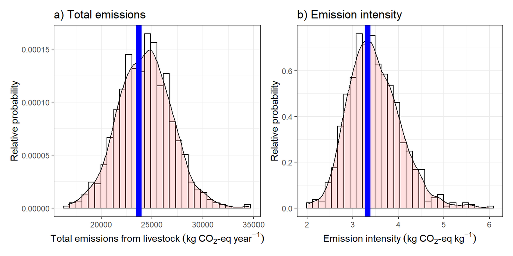

*Figure 1.* *Estimated total emissions from livestock (a) and emission intensity of milk production (b) for a smallholder dairy farm in Kenya. Plausible estimates of both metrics are generated through Monte Carlo simulation, based on 1000 runs of a greenhouse gas emissions model, with uncertainty introduced by specifying inputs as probability distributions. The blue line indicates a precise estimate based on precise results from a farm survey and default parameters recommended by various guidance documents.*

```r
scenarios<-read.csv("data/farm_scenarios.csv", fileEncoding = "UTF-8-BOM")
farm_5<-scenarios[,c(1,2,7)]

farm5_emissions<-scenario_mc(base_estimate = estimate_read_csv("data/livestock_ghg_input_table.csv"),
                             scenarios = farm_5,
                             model_function = ghg_emissions,
                             numberOfModelRuns = 1000,
                             functionSyntax = "plainNames")


precise_scenarios<-read.csv("data/farm_scenarios_precise.csv", fileEncoding = "UTF-8-BOM")

farm5_precise<-precise_scenarios[,c(1,2,7)]

farm5_emissions_precise<-scenario_mc(base_estimate = estimate_read_csv("data/livestock_ghg_input_table.csv"),
                             scenarios = farm5_precise,
                             model_function = ghg_emissions,
                             numberOfModelRuns = 10,
                             functionSyntax = "plainNames")

farm5a<-ggplot(data=farm5_emissions$y, aes(on_farm)) +
geom_histogram(aes(y=..density..), colour="black", fill="white")+
 geom_density(alpha=.2, fill="#FF6666") +
  ylab("Relative probability") +
    xlab(expression(Total~emissions~from~livestock~(kg~CO[2]*'-eq'~year^-1))) + theme_bw() + ggtitle("a) Total emissions")

farm5_total <- farm5a + geom_vline(data=farm5_emissions_precise$y, aes(xintercept=on_farm),color="blue", lwd=3)

farm5_emissions$y[,"CO2eq_per_milk"]<-farm5_emissions$y$pc_on_farm/farm5_emissions$y$pc_milk_yield

farm5b<-ggplot(data=farm5_emissions$y, aes(CO2eq_per_milk)) +
geom_histogram(aes(y=..density..), colour="black", fill="white")+
 geom_density(alpha=.2, fill="#FF6666") +
  ylab("Relative probability") +
    xlab(expression(Emission~intensity~(kg~CO[2]*'-eq'~kg^-1))) + ggtitle("b) Emission intensity")

farm5_emissions_precise$y[,"CO2eq_per_milk"]<-farm5_emissions_precise$y$pc_on_farm/farm5_emissions_precise$y$pc_milk_yield

farm5_intensity<-farm5b + geom_vline(data=farm5_emissions_precise$y, aes(xintercept=CO2eq_per_milk),color="blue", lwd=3) + theme_bw()

farm5_total+farm5_intensity
```

```r
ggsave("figures/Fig_1_emissions_from_farm_5.png",width=9,height=5)
```

Now we look at the overall population.

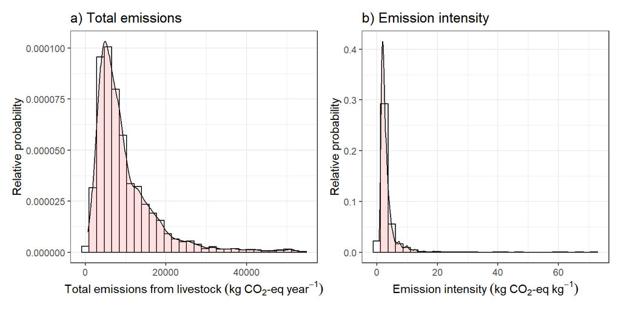

*Figure 2.* *Total greenhouse gas emissions from livestock (a) and emission intensity of milk production (b) across 4140 simulated livestock-keeping households in Kenya (informed by data collected on 414 farms). Plausible estimates of both metrics are generated through Monte Carlo simulation, based on 1000 runs of a greenhouse gas emissions model, with uncertainty introduced by specifying inputs as probability distributions.*

```r
all_farms_total<-ggplot(data=GHG_simulation_scenarios$y, aes(on_farm)) +
geom_histogram(aes(y=..density..), colour="black", fill="white")+
 geom_density(alpha=.2, fill="#FF6666") +
  ylab("Relative probability") +
    xlab(expression(Total~emissions~from~livestock~(kg~CO[2]*'-eq'~year^-1))) + theme_bw() + ggtitle("a) Total emissions")

all_farms_intensity<-ggplot(data=GHG_simulation_scenarios$y, aes(CO2eq_per_milk)) +
geom_histogram(aes(y=..density..), colour="black", fill="white")+
 geom_density(alpha=.2, fill="#FF6666") +
  ylab("Relative probability") + theme_bw() +
    xlab(expression(Emission~intensity~(kg~CO[2]*'-eq'~kg^-1))) + ggtitle("b) Emission intensity")

all_farms_total+all_farms_intensity
```

```r
ggsave("figures/Fig_2_emissions_from_all_farms.png",width=9,height=5)
```

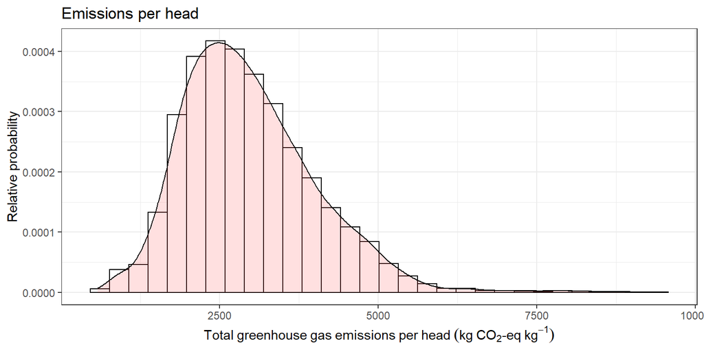

*Figure S1.* *Greenhouse gas emissions from livestock per head of cattle across 4140 simulated livestock-keeping households in Kenya (informed by data collected on 414 farms). Plausible estimates are generated through Monte Carlo simulation, based on 1000 runs of a greenhouse gas emissions model, with uncertainty introduced by specifying inputs as probability distributions.*

```r
all_farms_per_head<-ggplot(data=GHG_simulation_scenarios$y, aes(pc_on_farm)) +
geom_histogram(aes(y=..density..), colour="black", fill="white")+
 geom_density(alpha=.2, fill="#FF6666") +
  ylab("Relative probability") + theme_bw() +
    xlab(expression(Total~greenhouse~gas~emissions~per~head~(kg~CO[2]*'-eq'~kg^-1))) + ggtitle("Emissions per head")

all_farms_per_head
```

```r
ggsave("figures/Fig_S1_emissions_from_all_farms_per_head.png",width=9,height=5)
```

We can now look at summary statistics of total and per head emissions from cattle across livestock-keeping smallholder farms in Kenya. To exclude farms that do not appear to be specializing in livestock, some of which feature extremely high (up to infinity in cases where no milk is produced) emission intensity, we also look at summary statistics across only the farms with per head milk yields of >500 kg of milk.

```r
normal_milk_yield<-which(GHG_simulation_scenarios$y$pc_milk_yield>500)

dairy_households<-GHG_simulation_scenarios
dairy_households$x<-dairy_households$x[normal_milk_yield,]
dairy_households$y<-dairy_households$y[normal_milk_yield,]

emissions_summary<-rbind(data.frame("Emissions per farm"=round(quantile(GHG_simulation_scenarios$y$on_farm,
                                                                  c(0,0.05,0.5,0.95,1))/1000,1),
                                    "Emissions per head"=round(quantile(GHG_simulation_scenarios$y$pc_on_farm,
                                                                    c(0,0.05,0.5,0.95,1))/1000,1),
                                    "Emission intensity"=round(quantile(GHG_simulation_scenarios$y$CO2eq_per_milk,
                                                                   c(0,0.05,0.5,0.95,1)),1)),
                         data.frame("Emissions per farm"=round(quantile(dairy_households$y$on_farm,
                                                                  c(0,0.05,0.5,0.95,1))/1000,1),
                                    "Emissions per head"=round(quantile(dairy_households$y$pc_on_farm,
                                                                    c(0,0.05,0.5,0.95,1))/1000,1),
                                    "Emission intensity"=round(quantile(dairy_households$y$CO2eq_per_milk,
                                                                   c(0,0.05,0.5,0.95,1)),1)))
emissions_summary$Quantile<-c("Minimum","5% quantile", "Median", "95% quantile", "Maximum",
                              "Minimum","5% quantile", "Median", "95% quantile", "Maximum")
rownames(emissions_summary)<-NULL

kable(emissions_summary[,c(4,1,2,3)], booktabs = TRUE,
      col.names = c("Distribution attribute",
                    paste0("CO","$_2$","-eq farm","$^{-1}$"),
                    paste0("CO","$_2$","-eq head","$^{-1}$"),
                    paste0("CO","$_2$","-eq kg","$^{-1}$")),
      caption = "<p style='color:black'><i><b>Table S3.</b> Summary statistics of simulated greenhouse gas emissions from cattle across a population of cattle-keeping smallholder farms in Kenya</i></p>") %>% pack_rows(
  index = c("Emissions per farm" = 5, "Emissions per dairy-focused farm" = 5), background="lightgray") %>%
column_spec(2:4, width = "5cm") %>% row_spec(0, align = "c") %>%
  add_header_above(c(" " = 1, "Emissions per farm" = 1, "Emissions per head" = 1, "Emission intensity" = 1))
```

**Table S3.** Summary statistics of simulated greenhouse gas emissions from cattle across a population of cattle-keeping smallholder farms in Kenya

| Distribution attribute | Emissions per farm CO$_2$-eq farm$^{-1}$ | Emissions per head CO$_2$-eq head$^{-1}$ | Emission intensity CO$_2$-eq kg$^{-1}$ |
| --- | --- | --- | --- |
| **Emissions per farm** |  |  |  |
| Minimum | 0.6 | 0.6 | 0.6 |
| 5% quantile | 2.6 | 1.6 | 1.2 |
| Median | 7.4 | 2.8 | 2.5 |
| 95% quantile | 24.8 | 4.9 | Inf |
| Maximum | 54.5 | 9.4 | Inf |
| **Emissions per dairy-focused farm** |  |  |  |
| Minimum | 1.6 | 1.2 | 0.6 |
| 5% quantile | 3.2 | 1.8 | 1.2 |
| Median | 7.9 | 3.0 | 2.2 |
| 95% quantile | 26.4 | 5.0 | 4.3 |
| Maximum | 54.5 | 9.4 | 7.8 |

We’re interested in the suitability of total per head milk production per year as an indicator of the greenhouse gas emission intensity of milk production.

Here’s the relationship between these two variables, for farms with per-head milk yields of >500 kg per year.

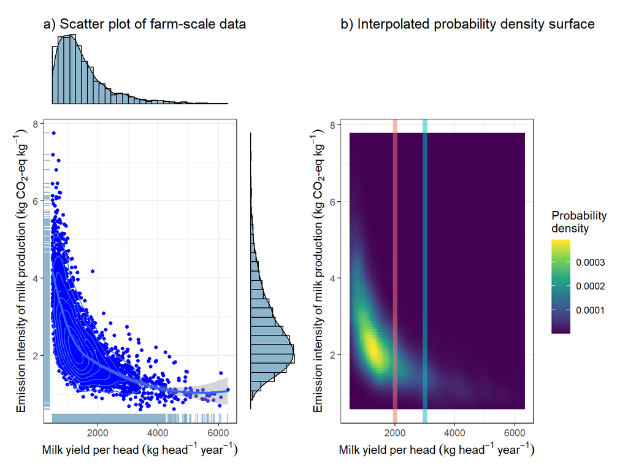

*Figure 3.* *Relationship between milk yield per head (x-axis) and emission intensity of milk production for livestock-keeping smallholder households in Kenya, expressed as a population-level scatter plot (a) and an interpolated probability density surface (b). The vertical lines in (b) illustrate slices through the density surface at productivity levels of 2000 (red) and 3000 (blue) kg milk head<sup>-1</sup> year<sup>-1</sup> (the corresponding distributions are shown in Fig. 4b).*

```r
plot1 <- ggplot(dairy_households$y, aes(x = pc_milk_yield, y = CO2eq_per_milk)) +
  geom_point(shape = 20, color = "blue", size = 2) +
  stat_smooth(method = "loess", fullrange = TRUE) +
  geom_density_2d() +
  geom_rug(color="lightskyblue3") +
  labs(y=expression(Emission~intensity~of~milk~production~(kg~CO[2]*'-eq'~kg^{-1})),
       x=expression(Milk~yield~per~head~(kg~head^{-1}~year^{-1})))+
  theme_bw() +
  theme(legend.position = c(0.15, 0.9))

dens1 <- ggplot(dairy_households$y, aes(x = pc_milk_yield)) +
  geom_histogram(aes(y = ..density..),
                 colour = 1, fill = "white") +
  geom_density(fill="lightskyblue3") +
  geom_histogram(aes(y = ..density..),
                 colour = 1, alpha=0) +
  theme_void() +
  theme(legend.position = "none") + ggtitle("a) Scatter plot of farm-scale data")

dens2 <- ggplot(dairy_households$y, aes(x = CO2eq_per_milk)) +
  geom_histogram(aes(y = ..density..),
                 colour = 1, fill = "white") +
  geom_density(fill="lightskyblue3") +
  geom_histogram(aes(y = ..density..),
                 colour = 1, alpha=0) +
  theme_void() +
  theme(legend.position = "none") +
  coord_flip()

scatt<-dens1 + plot_spacer() + plot1 + dens2 +
  plot_layout(ncol = 2, nrow = 2, widths = c(4, 1), heights = c(1, 4))


densi<-ggplot(dairy_households$y, aes(x = pc_milk_yield, y = CO2eq_per_milk)) +
  stat_density_2d(
    geom = "raster",
    aes(fill = after_stat(density)),
    contour = FALSE
    ) +
  scale_fill_viridis_c() +
  labs(y=expression(Emission~intensity~of~milk~production~(kg~CO[2]*'-eq'~kg^{-1})),
       x=expression(Milk~yield~per~head~(kg~head^{-1}~year^{-1})),
       fill="Probability \ndensity") +
  theme_bw() + geom_vline(xintercept=c(2000,3000),color=c("#F8766D","#00BFC4"),alpha=.5, lwd=2)


empty<-ggplot() +
    theme_void() +
    ggtitle("b) Interpolated probability density surface")

dens1 + plot_spacer() + empty + plot1 + dens2 + densi +
  plot_layout(ncol = 3, nrow = 2, widths = c(4, 1), heights = c(1, 4))
```

```r
ggsave("figures/Fig_3_scatter_and_surface_per_head_milk_emission_intensity.png",width=10,height=6)
```

Extracting the LOESS regression from the plot and empirically determining minimum milk yield that would be outside the confidence interval

```r
prediction_data<-ggplot_build(plot1)$data[[2]]
valuecrowd<-approx(prediction_data$x, y = prediction_data$ymax, xout= seq(100,10000,10), method="linear")

for(i in 1:nrow(prediction_data))
{
  closest<-min(which(valuecrowd$x>prediction_data$x[i] & valuecrowd$y<prediction_data$ymin[i]))
  prediction_data[i,"min_more_milk_loess"]<-valuecrowd$x[closest]
}
```

According to these distributions, the emission intensity at a particular per head milk yield can be described by a slice through the probability surface.

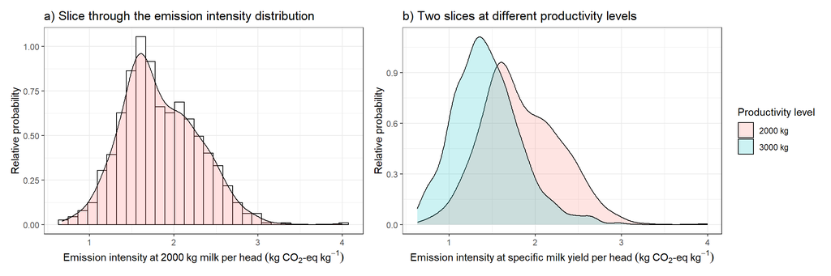

*Figure 4.* *Greenhouse gas emission intensity of milk production at specific levels of per-head milk production among livestock-keeping smallholder farms in Kenya. Distributions are shown for (a) a production level of 2000 kg milk head<sup>-1</sup> year<sup>-1</sup>, including a histogram of the random samples the distribution is based on, and (b) production levels of 2000 and 3000 kg milk head<sup>-1</sup> year<sup>-1</sup>.*

```r
slice_2000<-uncertainty::varslice_resample(in_var = dairy_households$y$pc_milk_yield,
                                 out_var = dairy_households$y$CO2eq_per_milk,
                                 expectedin_var=2000,
                           n = 1000,
                           n_samples = 1000,
                           out_var_sampling = 1000)
slice_3000<-uncertainty::varslice_resample(in_var = dairy_households$y$pc_milk_yield,
                                 out_var = dairy_households$y$CO2eq_per_milk,
                                 expectedin_var=3000,
                           n = 1000,
                           n_samples = 1000,
                           out_var_sampling = 1000)

one_slice<-ggplot(data=data.frame(CO2eq_per_milk=slice_2000$resampled), aes(CO2eq_per_milk)) +
geom_histogram(aes(y=..density..), colour="black", fill="white")+
 geom_density(alpha=.2, fill="#FF6666") +
  ylab("Relative probability") +
    xlab(expression(Emission~intensity~at~2000~kg~milk~per~head~(kg~CO[2]*'-eq'~kg^-1))) + theme_bw() + ggtitle("a) Slice through the emission intensity distribution")

slices<-rbind(data.frame(Values=slice_2000$resampled, Level="2000 kg"), data.frame(Values=slice_3000$resampled, Level="3000 kg"))

two_slices<-ggplot(data=slices, aes(Values, fill=Level)) +
 geom_density(alpha=.2) +
  ylab("Relative probability") +
    xlab(expression(Emission~intensity~at~specific~milk~yield~per~head~(kg~CO[2]*'-eq'~kg^-1))) + labs(fill='Productivity level') + theme_bw() + ggtitle("b) Two slices at different productivity levels")

one_slice + two_slices
```

```r
ggsave("figures/Fig_4_slices.png",width=13,height=6)
```

By resampling from these distributions, we can determine the likelihood that a value of one of these distributions is greater than one of the other. We can systematically expand this to include more comparisons, in this case at intervals of 100 kg milk yield per head.

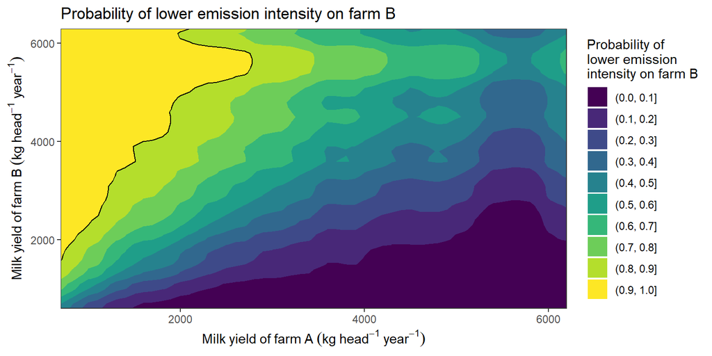

*Figure 5.* *Probability of a particular farm B featuring lower emission intensity of milk production than another farm A, based on observed per-head milk production levels. Estimates are derived from pairwise comparisons of slices through a population-wide generalization surface of the relationship between per-head milk production and emission intensity. This generalization was generated through Monte Carlo simulation, based on scenarios representing observed production settings on 414 livestock-keeping smallholder farms in Kenya.*

```r
milk_yields_to_sample<-seq(100,10000,100)
milk_yields_to_sample<-milk_yields_to_sample[which(milk_yields_to_sample<max(dairy_households$y$pc_milk_yield))]
milk_yields_to_sample<-milk_yields_to_sample[which(milk_yields_to_sample>min(dairy_households$y$pc_milk_yield))]
slices<-list()

# slice through the distribution at every 100 L milk yield per cow

for(i in 1:length(milk_yields_to_sample))
{slices[[i]]<-
  varslice_resample(dairy_households$y$pc_milk_yield,
                      dairy_households$y$CO2eq_per_milk,
                      expectedin_var = milk_yields_to_sample[i],
                      n_samples = 100000,
  out_var_sampling = 1000)$resample
 }

decreased_emissions_probability <-
  data.frame(Base_yield = NA,new_yield=NA,probability=NA)

for (i in 2:(length(milk_yields_to_sample) - 1))
{
  for (j in 1:length(milk_yields_to_sample))
    {decreased_emissions_probability[nrow(decreased_emissions_probability)+1,"Base_yield"]<-milk_yields_to_sample[i]
     decreased_emissions_probability$new_yield[nrow(decreased_emissions_probability)]<-milk_yields_to_sample[j]
     decreased_emissions_probability$probability[nrow(decreased_emissions_probability)] <-
      sum(slices[[i]] > slices[[j]]) / length(slices[[i]])
     decreased_emissions_probability$probability[nrow(decreased_emissions_probability)] <-
      sum(slices[[i]] > sample(slices[[j]], length(slices[[i]]))) / length(slices[[i]])

}
}

decreased_emissions_probability<-decreased_emissions_probability[which(!is.na(decreased_emissions_probability$Base_yield)),]


ggplot(data = decreased_emissions_probability, aes(Base_yield, new_yield)) + geom_contour_filled(aes(z =
                                                      probability)) +
  ggtitle("Probability of lower emission intensity on farm B") +
  labs(y=expression(Milk~yield~of~farm~B~(kg~head^{-1}~year^{-1})),
       x=expression(Milk~yield~of~farm~A~(kg~head^{-1}~year^{-1})),
       fill="Probability of \nlower emission \nintensity on farm B") +
  stat_contour(aes(z = probability),breaks = c(0.9),col="black") +
  theme_bw() +
  scale_x_continuous(limits=c(min(decreased_emissions_probability$Base_yield),NA),expand = c(0, 0)) +
  scale_y_continuous(limits=c(min(decreased_emissions_probability$new_yield),NA),expand = c(0, 0))
```

```r
ggsave("figures/Fig_5_probability_of_lower_emission_intensity.png", width=7,height=5)
```

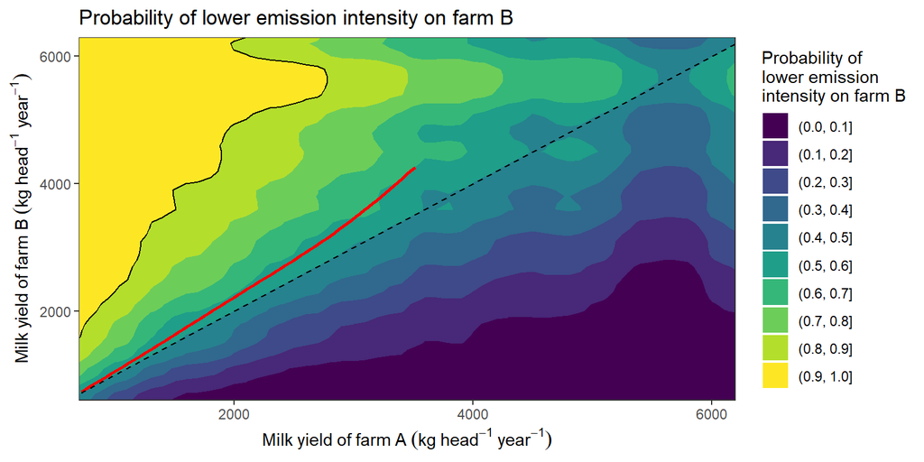

*Figure S2.* *Probability of a particular farm B featuring lower emission intensity of milk production than another farm A, based on observed per-head milk production levels (see caption to Fig. 5 for more details). The red line indicates a confidence threshold that is based on the 95% confidence interval of the LOESS regression line shown in Fig. 3a. Using this threshold for predicting changes in emission intensity based on milk yield data would likely lead to a lot of inaccurate classifications.*

```r
ggplot(data = decreased_emissions_probability, aes(Base_yield, new_yield)) + geom_contour_filled(aes(z =
                                                      probability)) +
  ggtitle("Probability of lower emission intensity on farm B") +
  labs(y=expression(Milk~yield~of~farm~B~(kg~head^{-1}~year^{-1})),
       x=expression(Milk~yield~of~farm~A~(kg~head^{-1}~year^{-1})),
       fill="Probability of \nlower emission \nintensity on farm B") +
  stat_contour(aes(z = probability),breaks = c(0.9),col="black") +
  geom_smooth(data=prediction_data, aes(x=x,y=min_more_milk_loess),col="red")  +  geom_abline(slope=1,intercept=0,linetype = "dashed")  +
  theme_bw() +
  scale_x_continuous(limits=c(min(decreased_emissions_probability$Base_yield),NA),expand = c(0, 0)) +
  scale_y_continuous(limits=c(min(decreased_emissions_probability$new_yield),NA),expand = c(0, 0))
```

```r
ggsave("figures/Fig_S2_probability_of_lower_emission_intensity.png", width=7,height=5)
```

Now a description of the 5 interventions

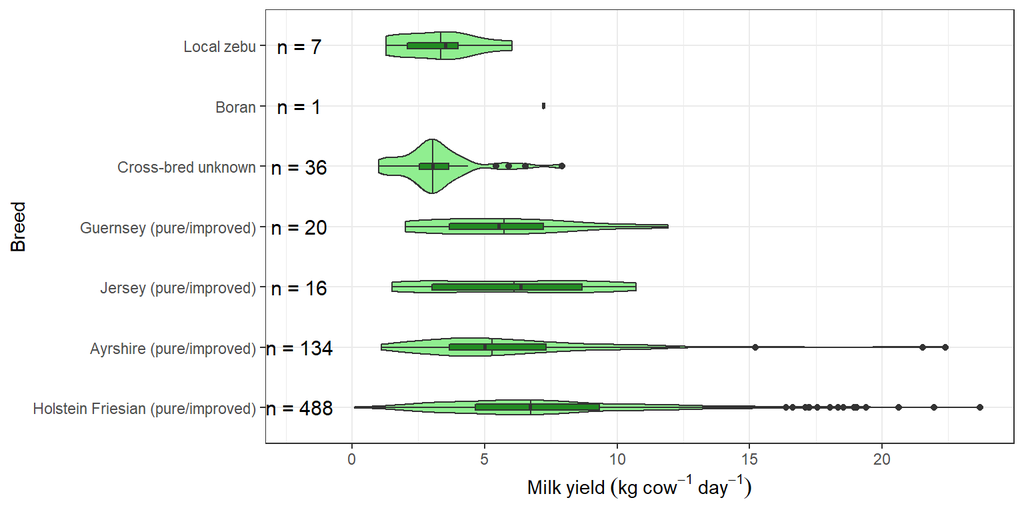

*Figure S3.* *Observed distributions of milk yields for all cattle breeds encountered among dairy cows in a survey of livestock-keeping smallholder farms in Kenya.*

```r
# breed intervention

cows<-Kenyaherds[which(Kenyaherds$animal_type %in% 4:6),]
cowcount<-data.frame(table(cows$breed))

breed_yield_plot<-ggplot(cows, aes(factor(breed),milk_yield)) +
  geom_violin(draw_quantiles=c(0.5),fill="light green") +
  xlab("Breed") + ylab(expression(Milk~yield~(kg~cow^{-1}~day^{-1}))) +
  geom_boxplot(width=0.1,fill="forestgreen") +
  theme_bw() +
  coord_flip() +
  scale_x_discrete(labels=c("Holstein Friesian (pure/improved)",
                            "Ayrshire (pure/improved)",
                            "Jersey (pure/improved)",
                            "Guernsey (pure/improved)",
                            "Cross-bred unknown",
                            "Boran",
                            "Local zebu")) +
  geom_text(data=cowcount ,aes(x = Var1, y = -2, label=paste("n =",Freq)),size = 4)

breed_milk_summary<-data.frame(Breed=c("Holstein Friesian (pure/improved)",
                            "Ayrshire (pure/improved)",
                            "Jersey (pure/improved)",
                            "Guernsey (pure/improved)",
                            "Cross-bred unknown",
                            "Boran",
                            "Local zebu"),
                            cow_number=cowcount$Freq,
                            milk_yield=round(ggplot_build(breed_yield_plot)$data[[2]]$middle,1),
                            intervention_factor= round(ggplot_build(breed_yield_plot)$data[[2]]$middle/
                             ggplot_build(breed_yield_plot)$data[[2]]$middle[1],2))
breed_milk_summary$intervention_factor[which(breed_milk_summary$Breed=="Boran")]<-1

breed_yield_plot
```

```r
ggsave("figures/Fig_S3_breeds.png", width=9,height=4)
```

```r
kable(breed_milk_summary, col.names = c("Breed", "Number of dairy cows", "Daily milk yield (kg)", "Intervention factor"),
      caption = "<p style='color:black'><i><b>Table S4.</b> Mean milk yield across all dairy cow breeds encountered during a farm survey in Kenya</i></p>") %>%
column_spec(2:4, width = "5cm")
```

| Breed | Number of dairy cows | Daily milk yield (kg) | Intervention factor |
| --- | --- | --- | --- |
| Holstein Friesian (pure/improved) | 488 | 6.7 | 1.00 |
| Ayrshire (pure/improved) | 134 | 5.0 | 0.75 |
| Jersey (pure/improved) | 16 | 6.4 | 0.95 |
| Guernsey (pure/improved) | 20 | 5.5 | 0.83 |
| Cross-bred unknown | 36 | 3.0 | 0.45 |
| Boran | 1 | 7.2 | 1.00 |
| Local zebu | 7 | 3.5 | 0.52 |

```r
milk_summary<-cbind(aggregate(cows$milk_yield, by=list(cows$breed), FUN=median),table(cows$breed))
milk_summary<-milk_summary[,c(1,4,2)]
colnames(milk_summary)<-c("Breed","n","Median_milk_yield")

milk_summary[,"Intervention_factor"]<-sapply(milk_summary$Median_milk_yield, function(x) min(x/milk_summary$Median_milk_yield[1],1))

live_weights<-aggregate(Kenyaherds$live_weight_LW, by=list(Kenyaherds$animal_type,Kenyaherds$breed), FUN=median)
colnames(live_weights)<-c("animal_type","breed","median_live_weight")
live_weights[,"Intervention_factor"]<-NA
for(i in 1:nrow(live_weights))
  live_weights$Intervention_factor[i]<-live_weights$median_live_weight[i]/
     live_weights$median_live_weight[which(live_weights$animal_type==live_weights$animal_type[i] &                                                                                                            live_weights$breed==1)]

# mature weight should probably be changed, and the code below does this. However, the mature weight is currently the same for all the breeds, so this accomplished nothing.

mature_weights<-aggregate(Kenyaherds$mature_weight_MW, by=list(Kenyaherds$animal_type,Kenyaherds$breed), FUN=median)
colnames(mature_weights)<-c("animal_type","breed","median_mature_weight")
mature_weights[,"Intervention_factor"]<-NA
for(i in 1:nrow(mature_weights))
  mature_weights$Intervention_factor[i]<-mature_weights$median_mature_weight[i]/
     mature_weights$median_mature_weight[which(mature_weights$animal_type==mature_weights$animal_type[i] &                                                                                                            mature_weights$breed==1)]

# same for the weight gain - doesn't depend on the breed at the moment, so all the factors are 1

weight_gains<-aggregate(Kenyaherds$weight_gain_WG, by=list(Kenyaherds$animal_type,Kenyaherds$breed), FUN=median)
colnames(weight_gains)<-c("animal_type","breed","median_weight_gain")
weight_gains[,"Intervention_factor"]<-NA
for(i in 1:nrow(weight_gains))
  weight_gains$Intervention_factor[i]<-weight_gains$median_weight_gain[i]/
     weight_gains$median_weight_gain[which(weight_gains$animal_type==weight_gains$animal_type[i] &                                                                                                            weight_gains$breed==1)]
weight_gains$Intervention_factor[which(weight_gains$median_weight_gain==0)]<-1

farms<-unique(Kenyaherds$QQNO)
breed_intervention<-data.frame(Farm=farms, milk_yield_4=1, milk_yield_5=1, milk_yield_6=1)

Kenyaherds_interventions<-Kenyaherds[,c("QQNO",
                                        "system",
                                        "animal_type",
                                        "breed",
                                        "live_weight_LW",
                                        "mature_weight_MW",
                                        "weight_gain_WG",
                                        "milk_yield",
                                        "dig_energy",
                                        "CP.")]

Kenyaherds_interventions[,"milk_change"]<-0
cows<-which(Kenyaherds_interventions$animal_type %in% 4:6)
Kenyaherds_interventions$milk_change[cows]<- sapply(cows,function(x) 1/milk_summary$Intervention_factor[milk_summary$Breed==Kenyaherds_interventions$breed[x]]  )

milk_change<-aggregate(Kenyaherds_interventions$milk_change[cows], by=list(Kenyaherds_interventions$QQNO[cows], Kenyaherds_interventions$animal_type[cows]), FUN=mean)

Milk_changes_4<-milk_change[which(milk_change$Group.2==4),]
breed_intervention$milk_yield_4[which(breed_intervention$Farm %in% Milk_changes_4[,1])]<-Milk_changes_4[,3]
Milk_changes_5<-milk_change[which(milk_change$Group.2==5),]
breed_intervention$milk_yield_5[which(breed_intervention$Farm %in% Milk_changes_5[,1])]<-Milk_changes_5[,3]
Milk_changes_6<-milk_change[which(milk_change$Group.2==6),]
breed_intervention$milk_yield_6[which(breed_intervention$Farm %in% Milk_changes_6[,1])]<-Milk_changes_6[,3]

for(i in 1:nrow(Kenyaherds_interventions))
  {Kenyaherds_interventions[i,"live_weight_change"]<-
    1/live_weights$Intervention_factor[which(live_weights$animal_type==Kenyaherds_interventions$animal_type[i]&
                                             live_weights$breed==Kenyaherds_interventions$breed[i])]
   Kenyaherds_interventions[i,"weight_gain_change"]<-
     1/weight_gains$Intervention_factor[which(weight_gains$animal_type==Kenyaherds_interventions$animal_type[i]&
                                              weight_gains$breed==Kenyaherds_interventions$breed[i])]
}

live_weight_agg<-aggregate(Kenyaherds_interventions$live_weight_change,
                           by=list(Kenyaherds_interventions$QQNO,Kenyaherds_interventions$animal_type), FUN=mean)
weight_gain_agg<-aggregate(Kenyaherds_interventions$weight_gain_change,
                           by=list(Kenyaherds_interventions$QQNO,Kenyaherds_interventions$animal_type), FUN=mean)

colnames(live_weight_agg)<-c("farm","animal_type","conv_factor")
colnames(weight_gain_agg)<-c("farm","animal_type","conv_factor")

for(i in 1:nrow(live_weight_agg))
  breed_intervention[which(breed_intervention$Farm==live_weight_agg$farm[i]),
                     paste0("live_weight_LW_",live_weight_agg$animal_type[i])]<-
    live_weight_agg$conv_factor[i]

for(i in 1:nrow(weight_gain_agg))
  breed_intervention[which(breed_intervention$Farm==weight_gain_agg$farm[i]),
                     paste0("weight_gain_WG_",weight_gain_agg$animal_type[i])]<-
    weight_gain_agg$conv_factor[i]

breed_intervention[is.na(breed_intervention)]<-1

x_breed_intervention <- GHG_simulation_scenarios$x

adoption_rate <- 1

intervention_adopters<-which(rbinom(nrow(x_breed_intervention),1,adoption_rate)==1)

for (i in 1:nrow(x_breed_intervention))
{
  if (i %in% intervention_adopters) # if farmers adopt, make changes in x file
    x_breed_intervention[i, colnames(breed_intervention)[2:ncol(breed_intervention)]] <-
      x_breed_intervention[i, colnames(breed_intervention)[2:ncol(breed_intervention)]] *
      breed_intervention[which(paste0("Farm_", breed_intervention$Farm) ==
                                 x_breed_intervention$Scenario[i]),
                         2:ncol(breed_intervention)]
}

breed_adopters<-which(!x_breed_intervention$milk_yield_4*x_breed_intervention$N_animal_type_4==GHG_simulation_scenarios$x$milk_yield_4*GHG_simulation_scenarios$x$N_animal_type_4 |
                        !x_breed_intervention$milk_yield_5*x_breed_intervention$N_animal_type_5==GHG_simulation_scenarios$x$milk_yield_5*GHG_simulation_scenarios$x$N_animal_type_5 |
                        !x_breed_intervention$milk_yield_6*x_breed_intervention$N_animal_type_6==GHG_simulation_scenarios$x$milk_yield_6*GHG_simulation_scenarios$x$N_animal_type_6)

## Herd intervention 1 - nobulls

x_nobull_intervention <- GHG_simulation_scenarios$x
nobull_adoption_rate <- 1.0
for (i in 1:nrow(x_nobull_intervention))
{
  if (rbinom(1, 1, nobull_adoption_rate)) # if farmers adopt, make changes in x file
    x_nobull_intervention$N_animal_type_1[i]<-0
}
nobull_adopters<-which(!x_nobull_intervention$N_animal_type_1==GHG_simulation_scenarios$x$N_animal_type_1)

## Herd intervention 2 - lessReplace

x_lessReplace_intervention <- GHG_simulation_scenarios$x
lessReplace_adoption_rate <- 0.23
for (i in 1:nrow(x_lessReplace_intervention))
{
  if (rbinom(1, 1, lessReplace_adoption_rate)) # if farmers adopt, make changes in x file
    x_lessReplace_intervention$N_animal_type_3[i]<-0
}
lessReplace_adopters<-which(!x_lessReplace_intervention$N_animal_type_3==GHG_simulation_scenarios$x$N_animal_type_3)

## Feed intervention 1 - Supplementary legume fodder

x_Calliandra_intervention <- GHG_simulation_scenarios$x
Calliandra_adoption_rate <- 0.3
for (i in 1:nrow(x_Calliandra_intervention))
{
  if (rbinom(1, 1, Calliandra_adoption_rate)) # if farmers adopt, make changes in x file
    {x_Calliandra_intervention$milk_yield_5[i]<-x_Calliandra_intervention$milk_yield_5[i]+0.156
     x_Calliandra_intervention$milk_yield_6[i]<-x_Calliandra_intervention$milk_yield_6[i]+0.156
     x_Calliandra_intervention$DE_perc[i]<-x_Calliandra_intervention$DE_perc[i]+0.14
     x_Calliandra_intervention$perc_crude_protein_diet[i]<-x_Calliandra_intervention$perc_crude_protein_diet[i]-0.07
     x_Calliandra_intervention$feed_prod_CO2[i]<-x_Calliandra_intervention$feed_prod_CO2[i]- (0.726 *
                                        sum(x_Calliandra_intervention[i,paste0("N_animal_type_",1:12)]))

  }
}
Calliandra_adopters<-which(!x_Calliandra_intervention$DE_perc==GHG_simulation_scenarios$x$DE_perc)

## Feed intervention 2 - Balanced diets

x_balance_intervention <- GHG_simulation_scenarios$x
balance_adoption_rate <- 0.14
for (i in 1:nrow(x_balance_intervention))
{
  if (rbinom(1, 1, balance_adoption_rate)) # if farmers adopt, make changes in x file
    {x_balance_intervention$milk_yield_5[i]<-x_balance_intervention$milk_yield_5[i]+0.75
     x_balance_intervention$milk_yield_6[i]<-x_balance_intervention$milk_yield_6[i]+0.75
     x_balance_intervention$feed_prod_CO2[i]<-x_balance_intervention$feed_prod_CO2[i]-(328.5 *
                    sum(x_balance_intervention[i,paste0("N_animal_type_",1:12)]))
  }
}
balance_adopters<-which(!x_balance_intervention$feed_prod_CO2==GHG_simulation_scenarios$x$feed_prod_CO2)
```

To run the interventions, we need a function to run the model with a specific set of x values.

```r
# single model-run function
run_model<-function(x_data,model)
  {
  varnames<-colnames(x_data)[which(!colnames(x_data)=="Scenario")]
  model_function_ <- function(x) {

    e <- as.list(sapply(X = varnames, FUN = function(i) as.numeric(unlist(x[i]))))
    eval(expr = body(model), envir = e)
  }
  y <- do.call(what = rbind, args = lapply(X = apply(X = x_data,
                                                     MARGIN = 1, FUN = model_function_), FUN = unlist))
  returnObject <- list(y = data.frame(y), x = data.frame(x_data))
  returnObject$call <- match.call()
  class(returnObject) <- cbind("mcSimulation", class(returnObject))
  return(returnObject)
}
```

```r
# run model for modified x file
breed_res <- run_model(x_breed_intervention, ghg_emissions)
nobull_res <- run_model(x_nobull_intervention, ghg_emissions)
lessReplace_res <- run_model(x_lessReplace_intervention, ghg_emissions)
Calliandra_res <- run_model(x_Calliandra_intervention, ghg_emissions)
balance_res <- run_model(x_balance_intervention, ghg_emissions)

breed_res$y[,"CO2eq_per_milk"]<-breed_res$y$pc_on_farm/breed_res$y$pc_milk_yield
nobull_res$y[,"CO2eq_per_milk"]<-nobull_res$y$pc_on_farm/nobull_res$y$pc_milk_yield
lessReplace_res$y[,"CO2eq_per_milk"]<-lessReplace_res$y$pc_on_farm/lessReplace_res$y$pc_milk_yield
Calliandra_res$y[,"CO2eq_per_milk"]<-Calliandra_res$y$pc_on_farm/Calliandra_res$y$pc_milk_yield
balance_res$y[,"CO2eq_per_milk"]<-balance_res$y$pc_on_farm/balance_res$y$pc_milk_yield

breed_res$call<-"multi-scenario call"
save_temperature_scenarios(breed_res,"results","Breed_intervention")
nobull_res$call<-"multi-scenario call"
save_temperature_scenarios(nobull_res,"results","Nobull_intervention")
lessReplace_res$call<-"multi-scenario call"
save_temperature_scenarios(lessReplace_res,"results","LessReplace_intervention")
Calliandra_res$call<-"multi-scenario call"
save_temperature_scenarios(Calliandra_res,"results","Calliandra_intervention")
balance_res$call<-"multi-scenario call"
save_temperature_scenarios(balance_res,"results","Balance_intervention")
```

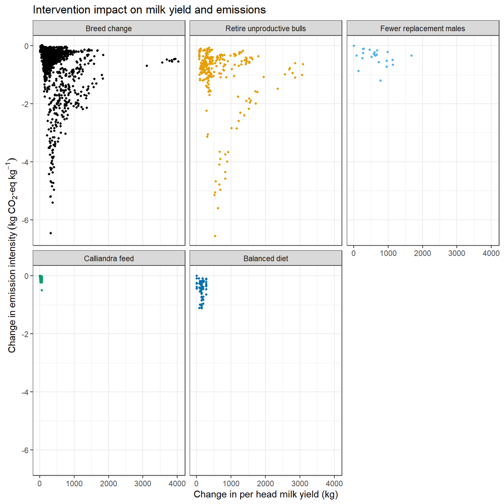

*Figure S4.* *Intervention impact on per head milk production and greenhouse gas emission intensity.*

```r
# make data.frame with all intervention results

interventions<-rbind(cbind(breed_res$y[breed_adopters,],
                           intervention="breed",
                           pc_milk_baseline=GHG_simulation_scenarios$y$pc_milk_yield[breed_adopters],
                           CO2_intensity_baseline=GHG_simulation_scenarios$y$CO2eq_per_milk[breed_adopters],
                           Farm=breed_res$x$Scenario[breed_adopters]),
                     cbind(nobull_res$y[nobull_adopters,],
                           intervention="nobull",
                           pc_milk_baseline=GHG_simulation_scenarios$y$pc_milk_yield[nobull_adopters],
                           CO2_intensity_baseline=GHG_simulation_scenarios$y$CO2eq_per_milk[nobull_adopters],
                           Farm=nobull_res$x$Scenario[nobull_adopters]),
                     cbind(lessReplace_res$y[lessReplace_adopters,],
                           intervention="lessReplace",
                           pc_milk_baseline=GHG_simulation_scenarios$y$pc_milk_yield[lessReplace_adopters],
                           CO2_intensity_baseline=GHG_simulation_scenarios$y$CO2eq_per_milk[lessReplace_adopters],
                           Farm=lessReplace_res$x$Scenario[lessReplace_adopters]),
                     cbind(Calliandra_res$y[Calliandra_adopters,],
                           intervention="Calliandra",
                           pc_milk_baseline=GHG_simulation_scenarios$y$pc_milk_yield[Calliandra_adopters],
                           CO2_intensity_baseline=GHG_simulation_scenarios$y$CO2eq_per_milk[Calliandra_adopters],
                           Farm=Calliandra_res$x$Scenario[Calliandra_adopters]),
                     cbind(balance_res$y[balance_adopters,],
                           intervention="balance",
                           pc_milk_baseline=GHG_simulation_scenarios$y$pc_milk_yield[balance_adopters],
                           CO2_intensity_baseline=GHG_simulation_scenarios$y$CO2eq_per_milk[balance_adopters],
                           Farm=balance_res$x$Scenario[balance_adopters]))


interventions[,"milk_change"]<-interventions$pc_milk_yield-interventions$pc_milk_baseline
interventions[,"emission_intensity_change"]<-interventions$CO2eq_per_milk-interventions$CO2_intensity_baseline
interventions[,"milk_change_relative"]<-(interventions$pc_milk_yield-interventions$pc_milk_baseline)/interventions$pc_milk_baseline*100
interventions[,"emission_intensity_change_relative"]<-
  (interventions$CO2eq_per_milk-interventions$CO2_intensity_baseline)/interventions$CO2_intensity_baseline*100


interventions_normal_milk<-interventions[which(interventions$pc_milk_yield>500),]

intervention_change <- merge(data.frame(aggregate(interventions_normal_milk$emission_intensity_change,
                                                  by = list(interventions_normal_milk$intervention),
                                                  FUN = mean)),
                             data.frame(aggregate(interventions_normal_milk$milk_change,
                                                  by = list(interventions_normal_milk$intervention),
                                                  FUN = mean)),
                             by = "Group.1")
colnames(intervention_change) <-
  c("intervention", "emission_intensity_change", "milk_change")

intervention_colors<-palette.colors(n = 6, palette = "Okabe-Ito", alpha=1, recycle = FALSE)

interventions_scatter<-ggplot(data=interventions_normal_milk,
                        aes(x=milk_change,y=emission_intensity_change)) +
  geom_point(aes(color=intervention),size=0.9) +
  theme_bw() +
  ggtitle("Intervention impact on milk yield and emissions") +
  labs(y=expression(Change~'in'~emission~intensity~(kg~CO[2]*'-eq'~kg^-1)),
       x="Change in per head milk yield (kg)",
       color="Intervention") +
  scale_color_manual(values= c("breed" = intervention_colors[1],
                              "nobull" = intervention_colors[2],
                              "lessReplace" = intervention_colors[3],
                              "Calliandra" = intervention_colors[4],
                              "balance" = intervention_colors[6]),
                    labels = c("Breed change", "No bulls", "Fewer males", "Calliandra feed", "Balanced diet")) +
  facet_wrap(~factor(intervention,
                     levels=c("breed","nobull","lessReplace","Calliandra","balance"),
                     labels=c("Breed change", "Retire unproductive bulls", "Fewer replacement males", "Calliandra feed", "Balanced diet"))  ) +
  theme(legend.position = "none")

interventions_scatter
```

```r
ggsave("figures/Fig_S4_intervention_impacts.png", width=9,height=6)
```

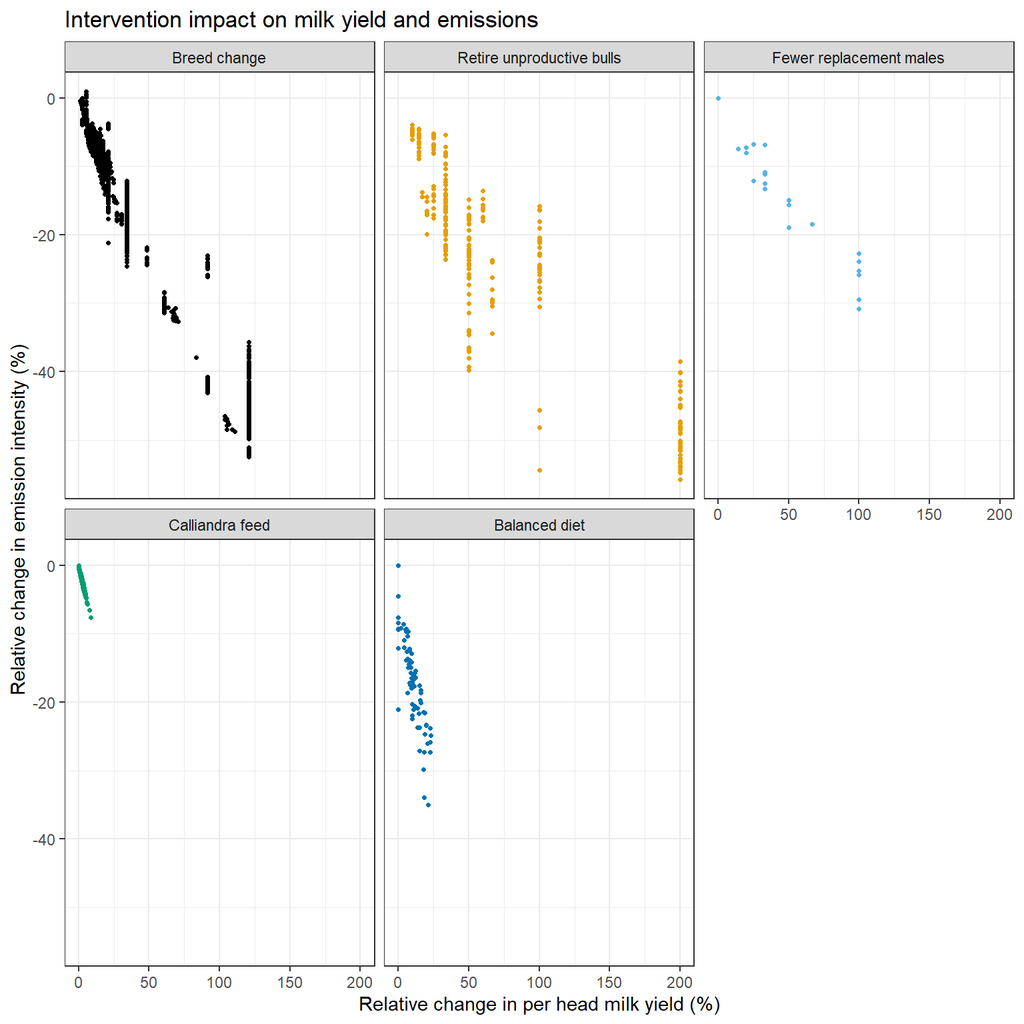

*Figure 6.* *Intervention impacts on relative per head milk production and relative greenhouse gas emission intensity, compared to a counterfactual farm with similar properties that does not implement the respective intervention.*

```r
interventions_scatter_relative<-ggplot(data=interventions_normal_milk,
                        aes(x=milk_change_relative,y=emission_intensity_change_relative)) +
  geom_point(aes(color=intervention),size=0.9) +
  theme_bw() +
  ggtitle("Intervention impact on milk yield and emissions") +
  labs(y="Relative change in emission intensity (%)",
       x="Relative change in per head milk yield (%)",
       color="Intervention") +
  scale_color_manual(values= c("breed" = intervention_colors[1],
                              "nobull" = intervention_colors[2],
                              "lessReplace" = intervention_colors[3],
                              "Calliandra" = intervention_colors[4],
                              "balance" = intervention_colors[6]),
                    labels = c("Breed change", "No bulls", "Fewer males", "Calliandra feed", "Balanced diet")) +
  facet_wrap(~factor(intervention,
                     levels=c("breed","nobull","lessReplace","Calliandra","balance"),
                     labels=c("Breed change", "Retire unproductive bulls", "Fewer replacement males", "Calliandra feed", "Balanced diet"))  ) +
  theme(legend.position = "none")

interventions_scatter_relative
```

```r
ggsave("figures/Fig_6_intervention_impacts_relative.png", width=9,height=6)
```

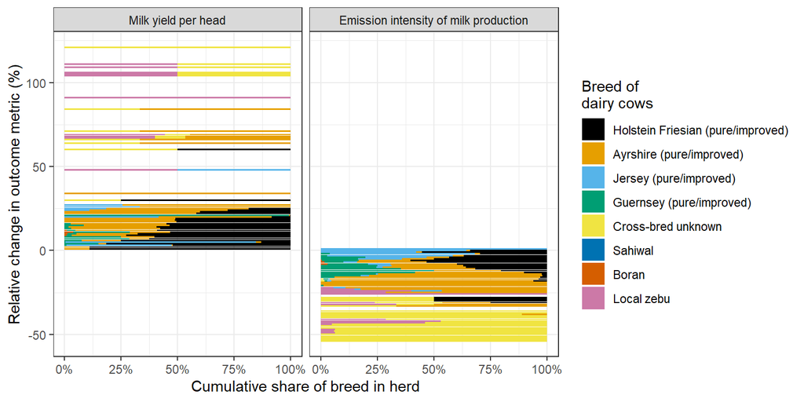

*Figure S5.* *Influence of the breed composition of farm-scale dairy cow populations on changes in milk yield and emission intensity of milk production in response to a breed change intervention*.

```r
interventions_diagnostics<-interventions

farm_structures<-data.frame(Farm_no=unique(Kenyaherds$QQNO))

for(f in farm_structures$Farm_no)
  {samp<-Kenyaherds[which(Kenyaherds$QQNO==f),]
   cows<-samp[which(samp$animal_type %in% 4:6),]
   farm_structures[which(farm_structures$Farm_no==f),"Farm"]<-paste0("Farm_",f)
   farm_structures[which(farm_structures$Farm_no==f),"breed_1"]<-length(which(cows$breed==1))/nrow(cows)
   farm_structures[which(farm_structures$Farm_no==f),"breed_2"]<-length(which(cows$breed==2))/nrow(cows)
   farm_structures[which(farm_structures$Farm_no==f),"breed_3"]<-length(which(cows$breed==3))/nrow(cows)
   farm_structures[which(farm_structures$Farm_no==f),"breed_4"]<-length(which(cows$breed==4))/nrow(cows)
   farm_structures[which(farm_structures$Farm_no==f),"breed_5"]<-length(which(cows$breed==5))/nrow(cows)
   farm_structures[which(farm_structures$Farm_no==f),"breed_6"]<-length(which(cows$breed==6))/nrow(cows)
   farm_structures[which(farm_structures$Farm_no==f),"breed_7"]<-length(which(cows$breed==7))/nrow(cows)
   farm_structures[which(farm_structures$Farm_no==f),"breed_8"]<-length(which(cows$breed==8))/nrow(cows)
   farm_structures[which(farm_structures$Farm_no==f),"unproductive_bulls"]<-
     length(which(samp$animal_type==1))/nrow(samp)
   farm_structures[which(farm_structures$Farm_no==f),"replacement_males"]<-
     length(which(samp$animal_type==3))/nrow(samp)

}

intervention_structures<-merge(interventions_diagnostics,farm_structures)
intervention_structures[,"not_unproductive_bulls"]<-1-intervention_structures$unproductive_bulls
intervention_structures[,"not_replacement_males"]<-1-intervention_structures$replacement_males


melted_breed<-melt(intervention_structures[,c("Farm",
                                              "intervention",
                                              "milk_change_relative",
                                              "emission_intensity_change_relative",
                                              paste0("breed_",1:8),
                                              "unproductive_bulls",
                                              "replacement_males")],
                   id.vars=c("Farm",
                             "intervention",
                             "milk_change_relative",
                             "emission_intensity_change_relative",
                             "unproductive_bulls",
                             "replacement_males"))
melted_breed<-melted_breed[which(!is.na(melted_breed$value)),]

#melted$Confidence_level_rounded<-round(melted$Confidence_level,2)*100

colnames(melted_breed)[which(colnames(melted_breed)=="value")]<-"breed_share"
colnames(melted_breed)[which(colnames(melted_breed)=="variable")]<-"breed"

metric_melt_breed<-melt(melted_breed,id.vars=c("Farm","intervention",
                                "unproductive_bulls","replacement_males","breed","breed_share"))
metric_melt_breed$value<-round(metric_melt_breed$value)
colnames(metric_melt_breed)[which(colnames(metric_melt_breed)=="value")]<-"change"
colnames(metric_melt_breed)[which(colnames(metric_melt_breed)=="variable")]<-"metric"

breedcol<-palette.colors(n = 8, palette = "Okabe-Ito", alpha=1, recycle = FALSE)

metrics <- c("Milk yield per head", "Emission intensity of milk production")
names(metrics) <- c("milk_change_relative","emission_intensity_change_relative")


breed_diagnostic<-
  ggplot(metric_melt_breed[which(metric_melt_breed$intervention=="breed"),], aes(group=breed, fill=breed, y=breed_share, x=change)) +
    geom_bar(position="fill", stat="identity") +
  scale_y_continuous(labels = scales::percent) + coord_flip() +
  labs(y="Cumulative share of breed in herd",
       x="Relative change in outcome metric (%)",
       fill="Breed of \ndairy cows") + scale_fill_manual(values= c("breed_1" = breedcol[1],
                                                                   "breed_2" = breedcol[2],
                                                                   "breed_3" = breedcol[3],
                                                                   "breed_4" = breedcol[4],
                                                                   "breed_5" = breedcol[5],
                                                                   "breed_6" = breedcol[6],
                                                                   "breed_7" = breedcol[7],
                                                                   "breed_8" = breedcol[8]),
                                               labels = c("Holstein Friesian (pure/improved)",
                                                          "Ayrshire (pure/improved)",
                                                          "Jersey (pure/improved)",
                                                          "Guernsey (pure/improved)",
                                                          "Cross-bred unknown",
                                                          "Sahiwal",
                                                          "Boran",
                                                          "Local zebu")) +
  theme_bw() + facet_wrap(~metric,
  labeller = labeller(metric = metrics))

breed_diagnostic
```

```r
ggsave("figures/Fig_S5_breed_diagnostics.png",width=8,height=5)
```

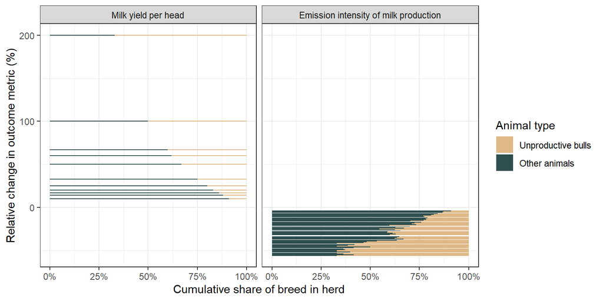

*Figure S6.* *Influence of the percentage of unproductive bulls in a cattle herd on changes in milk yield and emission intensity of milk production in response to a ‘retiring unproductive bulls’ intervention*.

```r
melted_nobull<-melt(intervention_structures[which(intervention_structures$intervention=="nobull"),
                                            c("Farm",
                                              "milk_change_relative",
                                              "emission_intensity_change_relative",
                                              "unproductive_bulls",
                                              "not_unproductive_bulls")],
                   id.vars=c("Farm",
                             "milk_change_relative",
                             "emission_intensity_change_relative"))

colnames(melted_nobull)[which(colnames(melted_nobull)=="value")]<-"percentage"
colnames(melted_nobull)[which(colnames(melted_nobull)=="variable")]<-"animal_type"

metric_melt_nobull<-melt(melted_nobull,
                         id.vars=c("Farm",
                                   "animal_type",
                                   "percentage"))
metric_melt_nobull$value<-round(metric_melt_nobull$value)
colnames(metric_melt_nobull)[which(colnames(metric_melt_nobull)=="value")]<-"change"
colnames(metric_melt_nobull)[which(colnames(metric_melt_nobull)=="variable")]<-"metric"

metrics <- c("Milk yield per head", "Emission intensity of milk production")
names(metrics) <- c("milk_change_relative","emission_intensity_change_relative")

metric_melt_nobull<-metric_melt_nobull[which(!is.na(metric_melt_nobull$change)),]

metric_melt_nobull$percentage<-round(metric_melt_nobull$percentage,2)

nobull_diagnostic<-
  ggplot(metric_melt_nobull, aes(group=animal_type, fill=animal_type, y=percentage, x=change)) +
    geom_bar(position="fill", stat="identity") +
  scale_y_continuous(labels = scales::percent) + coord_flip() +
  labs(y="Cumulative share of breed in herd",
       x="Relative change in outcome metric (%)",
       fill="Animal type") + scale_fill_manual(values= c("unproductive_bulls" = "burlywood",
                                                         "not_unproductive_bulls" = "darkslategrey"),
                                               labels = c("Unproductive bulls",
                                                          "Other animals")) +
  theme_bw() + facet_wrap(~metric,
  labeller = labeller(metric = metrics))

nobull_diagnostic
```

```r
ggsave("figures/Fig_S6_nobull_diagnostics.png",width=8,height=5)
```

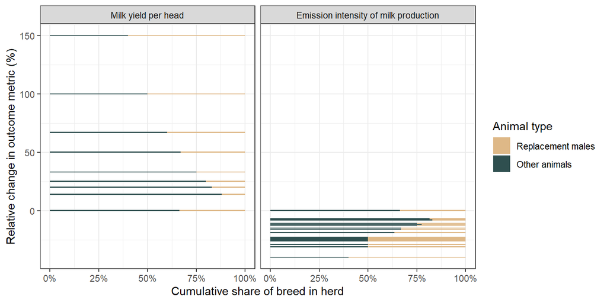

*Figure S7.* *Influence of the percentage of replacement males in a cattle herd on changes in milk yield and emission intensity of milk production in response to a ‘fewer replacement males’ intervention*.

```r
melted_lessReplace<-melt(intervention_structures[which(intervention_structures$intervention=="lessReplace"),
                                            c("Farm",
                                              "milk_change_relative",
                                              "emission_intensity_change_relative",
                                              "replacement_males",
                                              "not_replacement_males")],
                   id.vars=c("Farm",
                             "milk_change_relative",
                             "emission_intensity_change_relative"))

colnames(melted_lessReplace)[which(colnames(melted_lessReplace)=="value")]<-"percentage"
colnames(melted_lessReplace)[which(colnames(melted_lessReplace)=="variable")]<-"animal_type"

metric_melt_lessReplace<-melt(melted_lessReplace,
                         id.vars=c("Farm",
                                   "animal_type",
                                   "percentage"))
metric_melt_lessReplace$value<-round(metric_melt_lessReplace$value)
colnames(metric_melt_lessReplace)[which(colnames(metric_melt_lessReplace)=="value")]<-"change"
colnames(metric_melt_lessReplace)[which(colnames(metric_melt_lessReplace)=="variable")]<-"metric"

metrics <- c("Milk yield per head", "Emission intensity of milk production")
names(metrics) <- c("milk_change_relative","emission_intensity_change_relative")

metric_melt_lessReplace<-metric_melt_lessReplace[which(!is.na(metric_melt_lessReplace$change)),]

metric_melt_lessReplace$percentage<-round(metric_melt_lessReplace$percentage,2)

lessReplace_diagnostic<-
  ggplot(metric_melt_lessReplace, aes(group=animal_type, fill=animal_type, y=percentage, x=change)) +
    geom_bar(position="fill", stat="identity") +
  scale_y_continuous(labels = scales::percent) + coord_flip() +
  labs(y="Cumulative share of breed in herd",
       x="Relative change in outcome metric (%)",
       fill="Animal type") + scale_fill_manual(values= c("replacement_males" = "burlywood",
                                                         "not_replacement_males" = "darkslategrey"),
                                               labels = c("Replacement males",
                                                          "Other animals")) +
  theme_bw() + facet_wrap(~metric,
  labeller = labeller(metric = metrics))

lessReplace_diagnostic
```

```r
ggsave("figures/Fig_S7_lessReplace_diagnostics.png",width=8,height=5)
```

Summary statistics of interventions for the counterfactual simulation

```r
ints<-c("breed","nobull","lessReplace","Calliandra","balance")

interventions_summary_milk<-data.frame(Intervention=c("Breed change",
                                                 "Retiring unproductive bulls",
                                                 "Fewer replacement males",
                                                 "Calliandra feed",
                                                 "Balanced diet"))
interventions_summary_emissions<-interventions_summary_milk

for(i in 1:length(ints))
  {interventions_summary_milk[i,c("Weakest effect",
                                  "5% quantile",
                                  "Median effect",
                                  "95% quantile",
                                  "Strongest effect")]<-
    round(quantile(intervention_structures[which(intervention_structures$intervention==ints[i]),
                                           "milk_change_relative"],c(0,0.05,0.5,0.95,1),
                   na.rm=TRUE),1)
  interventions_summary_emissions[i,c("Weakest effect",
                                      "5% quantile",
                                      "Median effect",
                                      "95% quantile",
                                      "Strongest effect")]<-
    round(quantile(intervention_structures[which(intervention_structures$intervention==ints[i]),
                                           "emission_intensity_change_relative"],c(1,0.95,0.5,0.05,0),
                   na.rm=TRUE),1)}

intervention_summary<-rbind(interventions_summary_milk,interventions_summary_emissions)

kable(intervention_summary, booktabs = TRUE,digits=0,
     # col.names = c("Intervention",
       #             paste0("CO","$_2$","-eq farm","$^{-1}$"),
        #            paste0("CO","$_2$","-eq head","$^{-1}$"),
         #           paste0("CO","$_2$","-eq kg","$^{-1}$")),
      caption = "<p style='color:black'><i><b>Table S5.</b> Summary statistics of the simulated impact of farm-scale interventions aimed at reducing greenhouse gas emissions from cattle on cattle-keeping smallholder farms in Kenya. Impacts are evaluated against a true counterfactual baseline, in which all farms are identical except for the simulated impacts of the interventions.  </i></p>") %>%
  pack_rows(index = c("Impact on milk yield per head (%)" = 5, "Impact on emission intensity (%)" = 5), background="lightgray") %>%
column_spec(2:6, width = "3cm")
```

**Table S5.** Summary statistics of the simulated impact of farm-scale interventions aimed at reducing greenhouse gas emissions from cattle on cattle-keeping smallholder farms in Kenya. Impacts are evaluated against a true counterfactual baseline, in which all farms are identical except for the simulated impacts of the interventions.

| Intervention | Weakest effect | 5% quantile | Median effect | 95% quantile | Strongest effect |
| --- | --- | --- | --- | --- | --- |
| **Impact on milk yield per head (%)** |  |  |  |  |  |
| Breed change | 1 | 5 | 34 | 121 | 121 |
| Retiring unproductive bulls | 10 | 14 | 42 | 200 | 200 |
| Fewer replacement males | 0 | 0 | 0 | 100 | 150 |
| Calliandra feed | 0 | 0 | 0 | 4 | 17 |
| Balanced diet | 0 | 0 | 0 | 14 | 58 |
| **Impact on emission intensity (%)** |  |  |  |  |  |
| Breed change | 1 | -3 | -16 | -47 | -54 |
| Retiring unproductive bulls | -4 | -6 | -20 | -52 | -56 |
| Fewer replacement males | 0 | 0 | 0 | -24 | -40 |
| Calliandra feed | 0 | 0 | 0 | -4 | -15 |
| Balanced diet | 0 | 0 | 0 | -21 | -45 |

These are noticeable changes, but can they be detected against the random variation that all farms experience? We’ll now take another Monte Carlo sample, apply the same interventions to the same farms and evaluate the results again.

```r
## Run endline Monte Carlo simulation
GHG_simulation_scenarios_time2<-scenario_mc(base_estimate = estimate_read_csv("data/livestock_ghg_input_table.csv"),
                                            scenarios = read.csv("data/farm_scenarios.csv",
                                                                 fileEncoding = "UTF-8-BOM"),
                                            model_function = ghg_emissions,
                                            numberOfModelRuns = 10,
                                            functionSyntax = "plainNames")

GHG_simulation_scenarios_time2$call<-"multi-scenario call"
save_temperature_scenarios(GHG_simulation_scenarios_time2,"results","Endline_no_intervention")
```

```r
## Produce endline breed scenario
x_breed_intervention_endline <- GHG_simulation_scenarios_time2$x

for (i in breed_adopters)
{x_breed_intervention_endline[i, colnames(breed_intervention)[2:ncol(breed_intervention)]] <-
 x_breed_intervention_endline[i, colnames(breed_intervention)[2:ncol(breed_intervention)]] *
    breed_intervention[which(paste0("Farm_", breed_intervention$Farm) ==
                               x_breed_intervention_endline$Scenario[i]),
                       2:ncol(breed_intervention)]
}

## Herd intervention 1 - nobulls

x_nobull_intervention_endline <- GHG_simulation_scenarios_time2$x
x_nobull_intervention_endline$N_animal_type_1[nobull_adopters]<-0

## Herd intervention 2 - lessReplace

x_lessReplace_intervention_endline <- GHG_simulation_scenarios_time2$x
x_lessReplace_intervention_endline$N_animal_type_3[lessReplace_adopters]<-0

## Feed intervention 1 - Supplementary legume fodder

x_Calliandra_intervention_endline <- GHG_simulation_scenarios_time2$x
for (i in Calliandra_adopters)
{x_Calliandra_intervention_endline$milk_yield_5[i]<-x_Calliandra_intervention_endline$milk_yield_5[i]+0.156
 x_Calliandra_intervention_endline$milk_yield_6[i]<-x_Calliandra_intervention_endline$milk_yield_6[i]+0.156
 x_Calliandra_intervention_endline$DE_perc[i]<-x_Calliandra_intervention_endline$DE_perc[i]+0.14
 x_Calliandra_intervention_endline$perc_crude_protein_diet[i]<-x_Calliandra_intervention_endline$perc_crude_protein_diet[i]-0.07
 x_Calliandra_intervention_endline$feed_prod_CO2[i]<-x_Calliandra_intervention_endline$feed_prod_CO2[i]- (0.726 *
                                        sum(x_Calliandra_intervention_endline[i,paste0("N_animal_type_",1:12)]))
}


## Feed intervention 2 - Balanced diets

x_balance_intervention_endline <- GHG_simulation_scenarios_time2$x
for (i in balance_adopters)
{x_balance_intervention$milk_yield_5[i]<-x_balance_intervention$milk_yield_5[i]+0.75
 x_balance_intervention$milk_yield_6[i]<-x_balance_intervention$milk_yield_6[i]+0.75
 x_balance_intervention$feed_prod_CO2[i]<-x_balance_intervention$feed_prod_CO2[i]-(328.5 *
                    sum(x_balance_intervention[i,paste0("N_animal_type_",1:12)]))
}
```

```r
# run model for modified x file (endline)
breed_end <- run_model(x_breed_intervention_endline, ghg_emissions)
nobull_end <- run_model(x_nobull_intervention_endline, ghg_emissions)
lessReplace_end <- run_model(x_lessReplace_intervention_endline, ghg_emissions)
Calliandra_end <- run_model(x_Calliandra_intervention_endline, ghg_emissions)
balance_end <- run_model(x_balance_intervention_endline, ghg_emissions)

breed_end$y[,"CO2eq_per_milk"]<-breed_end$y$pc_on_farm/breed_end$y$pc_milk_yield
nobull_end$y[,"CO2eq_per_milk"]<-nobull_end$y$pc_on_farm/nobull_end$y$pc_milk_yield
lessReplace_end$y[,"CO2eq_per_milk"]<-lessReplace_end$y$pc_on_farm/lessReplace_end$y$pc_milk_yield
Calliandra_end$y[,"CO2eq_per_milk"]<-Calliandra_end$y$pc_on_farm/Calliandra_end$y$pc_milk_yield
balance_end$y[,"CO2eq_per_milk"]<-balance_end$y$pc_on_farm/balance_end$y$pc_milk_yield

breed_end$call<-"multi-scenario call"
save_temperature_scenarios(breed_end,"results","End_Breed_intervention")
nobull_end$call<-"multi-scenario call"
save_temperature_scenarios(nobull_end,"results","End_Nobull_intervention")
lessReplace_end$call<-"multi-scenario call"
save_temperature_scenarios(lessReplace_end,"results","End_LessReplace_intervention")
Calliandra_end$call<-"multi-scenario call"
save_temperature_scenarios(Calliandra_end,"results","End_Calliandra_intervention")
balance_end$call<-"multi-scenario call"
save_temperature_scenarios(balance_end,"results","End_Balance_intervention")
```

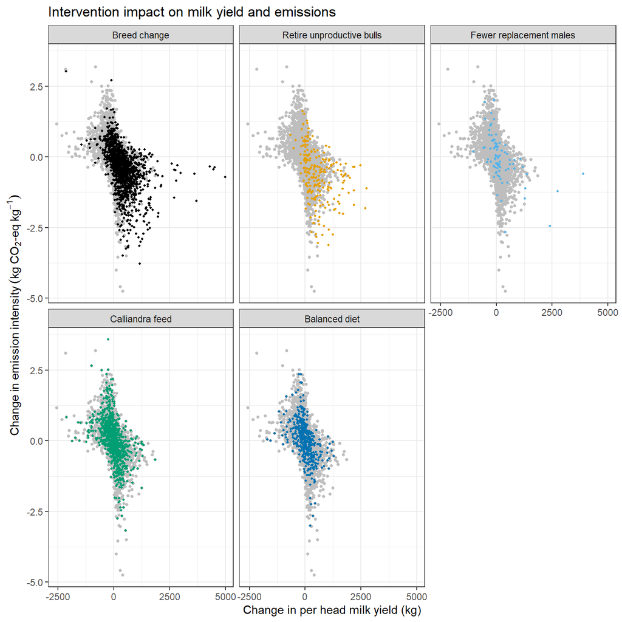

*Figure S8.* *Intervention impacts on milk production per head and greenhouse gas emission intensity, in comparison to random changes between two evaluation times. The gray dots illustrate random changes that occurred on farms that made no management changes, whereas the colored dots show changes on farms that implemented the respective interventions.*

```r
# make data.frame with all intervention results

interventions_end<-rbind(cbind(breed_end$y[breed_adopters,],
                           intervention="breed",
                           pc_milk_baseline=GHG_simulation_scenarios$y$pc_milk_yield[breed_adopters],
                           CO2_intensity_baseline=GHG_simulation_scenarios$y$CO2eq_per_milk[breed_adopters]),
                     cbind(nobull_end$y[nobull_adopters,],
                           intervention="nobull",
                           pc_milk_baseline=GHG_simulation_scenarios$y$pc_milk_yield[nobull_adopters],
                           CO2_intensity_baseline=GHG_simulation_scenarios$y$CO2eq_per_milk[nobull_adopters]),
                     cbind(lessReplace_end$y[lessReplace_adopters,],
                           intervention="lessReplace",
                           pc_milk_baseline=GHG_simulation_scenarios$y$pc_milk_yield[lessReplace_adopters],
                           CO2_intensity_baseline=GHG_simulation_scenarios$y$CO2eq_per_milk[lessReplace_adopters]),
                     cbind(Calliandra_end$y[Calliandra_adopters,],
                           intervention="Calliandra",
                           pc_milk_baseline=GHG_simulation_scenarios$y$pc_milk_yield[Calliandra_adopters],
                           CO2_intensity_baseline=GHG_simulation_scenarios$y$CO2eq_per_milk[Calliandra_adopters]),
                     cbind(balance_end$y[balance_adopters,],
                           intervention="balance",
                           pc_milk_baseline=GHG_simulation_scenarios$y$pc_milk_yield[balance_adopters],
                           CO2_intensity_baseline=GHG_simulation_scenarios$y$CO2eq_per_milk[balance_adopters]))

normal_end<-cbind(GHG_simulation_scenarios_time2$y,
                           pc_milk_baseline=GHG_simulation_scenarios$y$pc_milk_yield,
                           CO2_intensity_baseline=GHG_simulation_scenarios$y$CO2eq_per_milk)
normal_end[,"CO2eq_per_milk"]<-normal_end$pc_on_farm/normal_end$pc_milk_yield


interventions_end[,"milk_change"]<-interventions_end$pc_milk_yield-interventions_end$pc_milk_baseline
interventions_end[,"emission_intensity_change"]<-interventions_end$CO2eq_per_milk-interventions_end$CO2_intensity_baseline
interventions_end[,"milk_change_relative"]<-(interventions_end$pc_milk_yield-interventions_end$pc_milk_baseline)/interventions_end$pc_milk_baseline*100
interventions_end[,"emission_intensity_change_relative"]<-
  (interventions_end$CO2eq_per_milk-interventions_end$CO2_intensity_baseline)/interventions_end$CO2_intensity_baseline*100

normal_end[,"milk_change"]<-normal_end$pc_milk_yield-normal_end$pc_milk_baseline
normal_end[,"emission_intensity_change"]<-normal_end$CO2eq_per_milk-normal_end$CO2_intensity_baseline
normal_end[,"milk_change_relative"]<-(normal_end$pc_milk_yield-normal_end$pc_milk_baseline)/normal_end$pc_milk_baseline*100
normal_end[,"emission_intensity_change_relative"]<-
  (normal_end$CO2eq_per_milk-normal_end$CO2_intensity_baseline)/normal_end$CO2_intensity_baseline*100




interventions_normal_milk_end<-interventions_end[which(interventions_end$pc_milk_baseline>500),]
normal_normal_milk_end<-normal_end[which(normal_end$pc_milk_yield>500),]
normal_plot<-rbind(cbind(normal_normal_milk_end,intervention="breed"),
                   cbind(normal_normal_milk_end,intervention="nobull"),
                   cbind(normal_normal_milk_end,intervention="lessReplace"),
                   cbind(normal_normal_milk_end,intervention="Calliandra"),
                   cbind(normal_normal_milk_end,intervention="balance"))

intervention_colors<-palette.colors(n = 6, palette = "Okabe-Ito", alpha=1, recycle = FALSE)

interventions_scatter_end<-ggplot(data=normal_plot,
                        aes(x=milk_change,y=emission_intensity_change)) +
  geom_point(color="gray",size=1) +
  geom_point(data=interventions_normal_milk_end,
                        aes(x=milk_change,y=emission_intensity_change, color=intervention),size=0.8) +
  scale_color_manual(values= c("breed" = intervention_colors[1],
                              "nobull" = intervention_colors[2],
                              "lessReplace" = intervention_colors[3],
                              "Calliandra" = intervention_colors[4],
                              "balance" = intervention_colors[6]),
                    labels = c("Breed change", "No bulls", "Fewer males", "Calliandra feed", "Balanced diet")) +
  theme_bw() +
  ggtitle("Intervention impact on milk yield and emissions") +
  labs(y=expression(Change~'in'~emission~intensity~(kg~CO[2]*'-eq'~kg^-1)),
       x="Change in per head milk yield (kg)",
       color="Intervention")  +
  facet_wrap(~factor(intervention,
                     levels=c("breed","nobull","lessReplace","Calliandra","balance"),
                     labels=c("Breed change", "Retire unproductive bulls", "Fewer replacement males", "Calliandra feed", "Balanced diet"))  ) +
  theme(legend.position = "none")

interventions_scatter_end
```

```r
ggsave("figures/Fig_S8_intervention_impacts_endline.png", width=9,height=6)
```

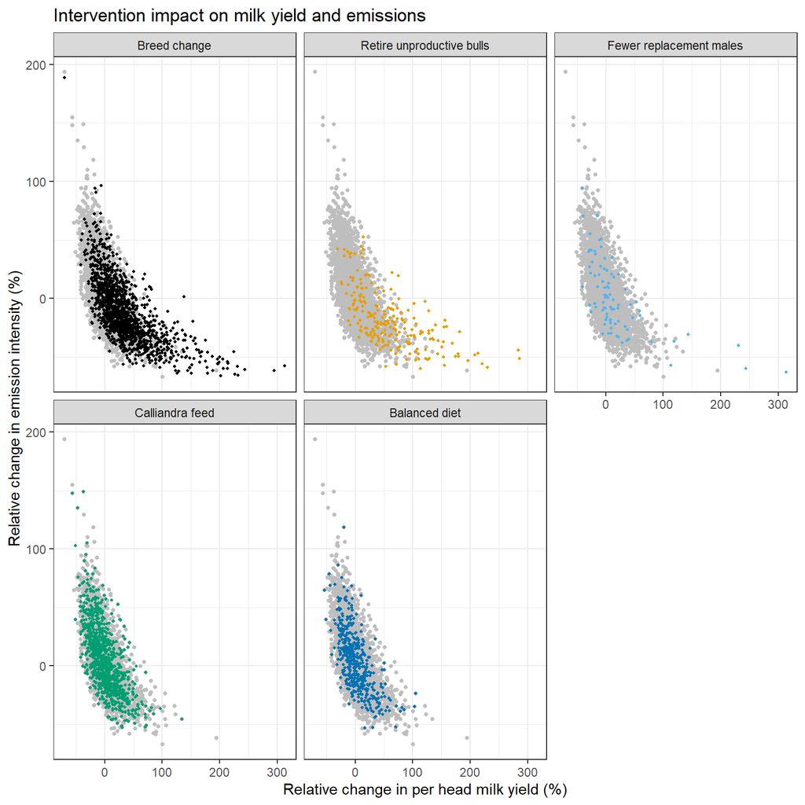

*Figure 7.* *Relative intervention impacts on milk production per head and greenhouse gas emission intensity, in comparison to random changes between two evaluation times. The gray dots illustrate random changes that occurred on farms that made no management changes, whereas the colored dots show changes on farms that implemented the respective interventions.*

```r
interventions_scatter_relative_end<-ggplot(data=normal_plot,
                        aes(x=milk_change_relative,y=emission_intensity_change_relative)) +
  geom_point(color="gray",size=1) +
  geom_point(data=interventions_normal_milk_end,
                        aes(x=milk_change_relative,y=emission_intensity_change_relative, color=intervention),size=0.8) +
  scale_color_manual(values= c("breed" = intervention_colors[1],
                              "nobull" = intervention_colors[2],
                              "lessReplace" = intervention_colors[3],
                              "Calliandra" = intervention_colors[4],
                              "balance" = intervention_colors[6]),
                    labels = c("Breed change", "No bulls", "Fewer males", "Calliandra feed", "Balanced diet")) +
  theme_bw() +
  ggtitle("Intervention impact on milk yield and emissions") +
  labs(y="Relative change in emission intensity (%)",
       x="Relative change in per head milk yield (%)",
       color="Intervention") +
  facet_wrap(~factor(intervention,
                     levels=c("breed","nobull","lessReplace","Calliandra","balance"),
                     labels=c("Breed change", "Retire unproductive bulls", "Fewer replacement males", "Calliandra feed", "Balanced diet"))  ) +
  theme(legend.position = "none")

interventions_scatter_relative_end
```

```r
ggsave("figures/Fig_7_intervention_impacts_endline_relative.png", width=9,height=6)
```

Summary statistics of interventions for the realistic-endline simulation

```r
ints<-c("breed","nobull","lessReplace","Calliandra","balance")

interventions_end_summary_milk<-data.frame(Intervention=c("Breed change",
                                                 "Retiring unproductive bulls",
                                                 "Fewer replacement males",
                                                 "Calliandra feed",
                                                 "Balanced diet",
                                                 "No intervention"))
interventions_end_summary_emissions<-interventions_end_summary_milk

for(i in 1:length(ints))
  {interventions_end_summary_milk[i,c("Weakest effect",
                                  "5% quantile",
                                  "Median effect",
                                  "95% quantile",
                                  "Strongest effect")]<-
    round(quantile(interventions_normal_milk_end[which(interventions_normal_milk_end$intervention==ints[i]),
                                           "milk_change_relative"],c(0,0.05,0.5,0.95,1),
                                      na.rm=TRUE),1)
interventions_end_summary_emissions[i,c("Weakest effect",
                                      "5% quantile",
                                      "Median effect",
                                      "95% quantile",
                                      "Strongest effect")]<-
    round(quantile(interventions_normal_milk_end[which(interventions_normal_milk_end$intervention==ints[i]),
                                           "emission_intensity_change_relative"],c(1,0.95,0.5,0.05,0),
                   na.rm=TRUE),1)}

interventions_end_summary_milk[6,c("Weakest effect",
                                      "5% quantile",
                                      "Median effect",
                                      "95% quantile",
                                      "Strongest effect")]<-
  round(quantile(normal_normal_milk_end[,"milk_change_relative"],
                 c(0,0.05,0.5,0.95,1),
                 na.rm=TRUE),1)
interventions_end_summary_emissions[6,c("Weakest effect",
                                      "5% quantile",
                                      "Median effect",
                                      "95% quantile",
                                      "Strongest effect")]<-
  round(quantile(normal_normal_milk_end[,"emission_intensity_change_relative"],
                 c(1,0.95,0.5,0.05,0),
                 na.rm=TRUE),1)

intervention_end_summary<-rbind(interventions_end_summary_milk,interventions_end_summary_emissions)

kable(intervention_end_summary, booktabs = TRUE,digits=0,
      caption = "<p style='color:black'><i><b>Table S6.</b> Summary statistics of the simulated impact of farm-scale interventions aimed at reducing greenhouse gas emissions from cattle on cattle-keeping smallholder farms in Kenya. Results are based on comparison of a baseline scenario, where no farm was assumed to have implemented the interventions and an endline scenarios, where some farms adopted the mitigation measures. At both baseline and endline, variation in outcomes expected to result from random effects was simulated using Monte Carlo simulation (10 runs per farm, for 414 farms).</i></p>") %>%
  pack_rows(index = c("Impact on milk yield per head (%)" = 6, "Impact on emission intensity (%)" = 6), background="lightgray") %>%
column_spec(2:6, width = "3cm")
```

**Table S6.** Summary statistics of the simulated impact of farm-scale interventions aimed at reducing greenhouse gas emissions from cattle on cattle-keeping smallholder farms in Kenya. Results are based on comparison of a baseline scenario, where no farm was assumed to have implemented the interventions and an endline scenarios, where some farms adopted the mitigation measures. At both baseline and endline, variation in outcomes expected to result from random effects was simulated using Monte Carlo simulation (10 runs per farm, for 414 farms).

| Intervention | Weakest effect | 5% quantile | Median effect | 95% quantile | Strongest effect |
| --- | --- | --- | --- | --- | --- |
| **Impact on milk yield per head (%)** |  |  |  |  |  |
| Breed change | -70 | -17 | 27 | 121 | 313 |
| Retiring unproductive bulls | -31 | -10 | 48 | 169 | 286 |
| Fewer replacement males | -41 | -28 | 4 | 118 | 314 |
| Calliandra feed | -56 | -32 | -2 | 42 | 134 |
| Balanced diet | -54 | -28 | -2 | 45 | 105 |
| No intervention | -70 | -31 | -1 | 45 | 194 |
| **Impact on emission intensity (%)** |  |  |  |  |  |
| Breed change | 189 | 36 | -15 | -49 | -66 |
| Retiring unproductive bulls | 52 | 35 | -22 | -52 | -60 |
| Fewer replacement males | 94 | 50 | -5 | -38 | -63 |
| Calliandra feed | 149 | 54 | 0 | -36 | -53 |
| Balanced diet | 118 | 51 | 2 | -35 | -53 |
| No intervention | 194 | 55 | 0 | -35 | -67 |

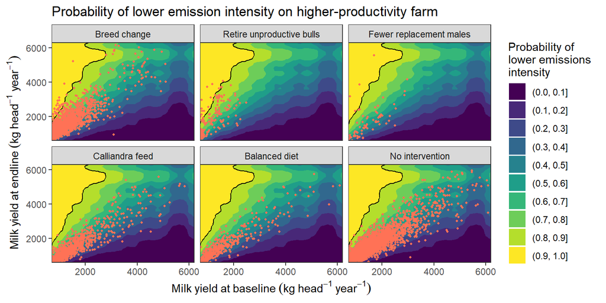

*Figure 8.* *Intervention impacts on milk yield and greenhouse gas emission intensity at an endline sampling point vs. the initial sampling time. The colored background surface indicates the probability that increases in milk productivity are associated with decreasing emission intensity.*

```r
interventions_plot<-interventions_normal_milk_end
none_plot<-cbind(normal_normal_milk_end,intervention="none")
int_none_plot<-rbind(interventions_plot,none_plot)

interventions_probability<-ggplot(data = decreased_emissions_probability, aes(Base_yield, new_yield)) +
  geom_contour_filled(aes(z=probability)) +
  ggtitle("Probability of lower emission intensity on higher-productivity farm") +
  labs(y=expression(Milk~yield~at~endline~(kg~head^{-1}~year^{-1})),
       x=expression(Milk~yield~at~baseline~(kg~head^{-1}~year^{-1})),
       fill="Probability of \nlower emissions \nintensity") +
  stat_contour(aes(z=probability),breaks = c(0.9),col="black") + theme_bw() +
  geom_point(data=int_none_plot,aes(x=pc_milk_baseline,y=pc_milk_yield), size=0.8, color="coral1") +
  ylim(c(0,NA)) + xlim(c(0,NA)) +
  facet_wrap(~factor(intervention,
                     levels=c("breed","nobull","lessReplace","Calliandra","balance","none"),
                     labels=c("Breed change", "Retire unproductive bulls", "Fewer replacement males", "Calliandra feed", "Balanced diet", "No intervention"))  ) +
  scale_x_continuous(limits=c(min(decreased_emissions_probability$Base_yield),max(decreased_emissions_probability$Base_yield)),expand = c(0, 0)) +
  scale_y_continuous(limits=c(min(decreased_emissions_probability$new_yield),max(decreased_emissions_probability$new_yield)),expand = c(0, 0))
interventions_probability
```

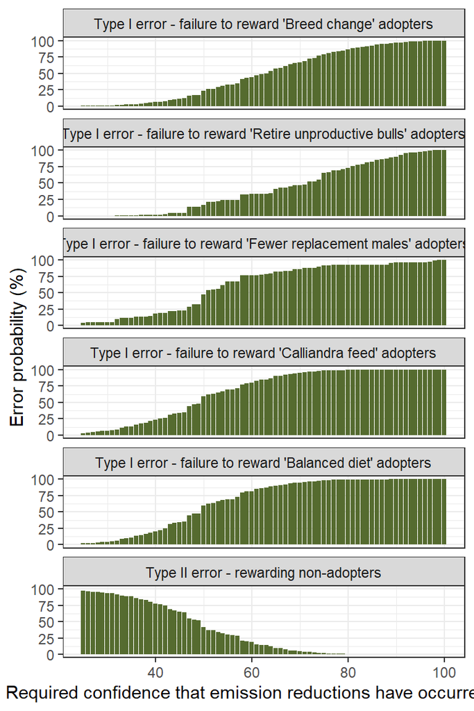

*Figure 9.* *Probability of Type I and Type II errors incurred by choosing specific levels of confidence that emission intensity changes have actually occurred. Type I errors indicate the probability of failing to recognize households that implemented interventions, whereas the Type II error represents the percentage of households that did not make any changes, but are nevertheless rewarded due to random effects.*

```r
ggsave("figures/Fig_8_probability_of_lower_emission_intensity_interventions.png", width=7,height=5)
# get closest probability value

for(i in 1:nrow(int_none_plot))
  {decreased_emissions_probability[,"diff"]<-
    abs(decreased_emissions_probability$Base_yield-int_none_plot$pc_milk_baseline [i]) +
    abs(decreased_emissions_probability$new_yield-int_none_plot$pc_milk_yield[i])
  int_none_plot[i,"confidence_level"]<-decreased_emissions_probability$probability[which(decreased_emissions_probability$diff==min(decreased_emissions_probability$diff))][1]
}

confidence_level_analysis<-data.frame(confidence=seq(0.25,1,0.01))

for(i in 1:nrow(confidence_level_analysis))
{# compute Type 1 errors for all interventions
  for(ints in c("breed", "nobull", "lessReplace", "Calliandra", "balance"))
    confidence_level_analysis[i,ints]<-
      length(which(int_none_plot$intervention==ints &
                     int_none_plot$confidence_level <
                     confidence_level_analysis$confidence[i])) /
      length(which(int_none_plot$intervention==ints)) * 100

  confidence_level_analysis$Type2error[i]<-
    length(which(int_none_plot$intervention=="none" &
                   int_none_plot$confidence_level>confidence_level_analysis$confidence[i])) /
    length(which(int_none_plot$intervention=="none")) * 100

}

confidence_level_analysis$confidence<-confidence_level_analysis$confidence*100
confidence_plot<-melt(confidence_level_analysis,id.vars = "confidence")
confidence_plot$variable <- factor(confidence_plot$variable, levels = c("breed", "nobull", "lessReplace", "Calliandra", "balance", "Type2error"),
                  labels = c("Type I error - failure to reward 'Breed change' adopters",
                             "Type I error - failure to reward 'Retire unproductive bulls' adopters",
                             "Type I error - failure to reward 'Fewer replacement males' adopters",
                             "Type I error - failure to reward 'Calliandra feed' adopters",
                             "Type I error - failure to reward 'Balanced diet' adopters",
                             "Type II error - rewarding non-adopters"))

ggplot(confidence_plot, aes(x=confidence,y=value)) + geom_bar(stat="identity", fill="darkolivegreen") + facet_wrap(~ variable,nrow=6) + theme_bw() +
  labs(y="Error probability (%)", x="Required confidence that emission reductions have occurred (%)")
```

```r
ggsave("figures/Fig_9_erorr_types.png", width=5,height=6)
```

and now for the sensitivity analysis

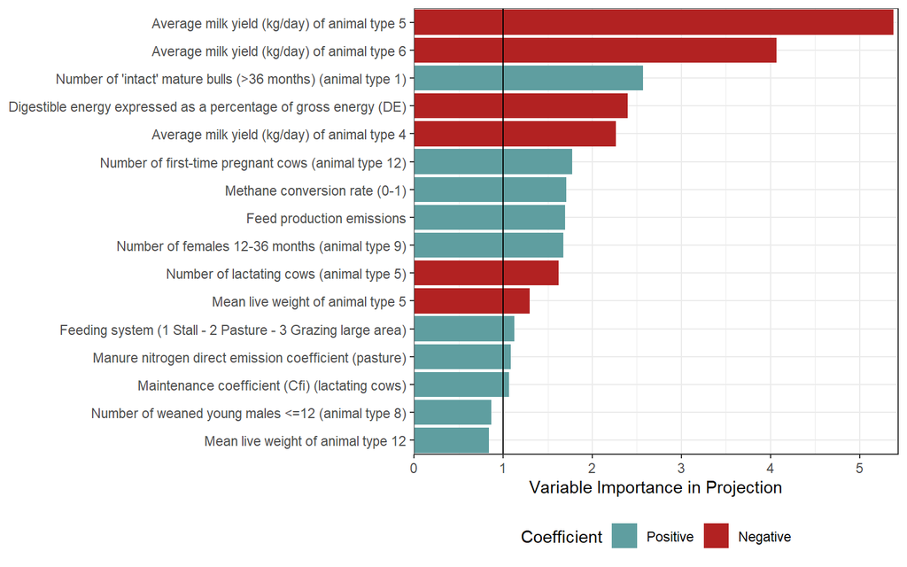

*Figure 10.* *Strength of the relationship of Monte Carlo model input variables with the emission intensity of milk production, as indicated by the Variable-Importance-Score of a Partial Least Squares regression.*

```r
pls_GHG<-dairy_households
pls_GHG$x<-pls_GHG$x[,which(!colnames(pls_GHG$x)=="Scenario")]

pls_out<-plsr.mcSimulation(object=pls_GHG, resultName = "CO2eq_per_milk")

legend_table<-read.csv("data/legend.csv", fileEncoding = "UTF-8-BOM")

plot_pls(pls_out,input_table=legend_table)
```

```r
ggsave("figures/Fig_10_PLS_dairy_households.png", width=8,height=5)
```

# 3 Narrowing key uncertainties

The sensitivity analysis indicated that uncertainty about milk yields is a key driver of output variation, with unfavorable implications for using this metric as an indicator of emission intensity. Published evidence suggests that, with some additional effort, this uncertainty can be reduced to a measurement error of approximately 15%. We can explore the impact of such measures on the suitability of milk yield per head as an indicator of emission intensity.

```r
scen_upd<-scenarios

new_error<-0.15

mean_milk_4<-(as.numeric(scen_upd[which(scen_upd$Variable=="milk_yield_4"&scen_upd$param=="lower"),3:ncol(scen_upd)]) +
  as.numeric(scen_upd[which(scen_upd$Variable=="milk_yield_4"&scen_upd$param=="upper"),3:ncol(scen_upd)])) / 2
scen_upd[which(scen_upd$Variable=="milk_yield_4"&scen_upd$param=="lower"),3:ncol(scen_upd)]<-mean_milk_4*(1-new_error)
scen_upd[which(scen_upd$Variable=="milk_yield_4"&scen_upd$param=="upper"),3:ncol(scen_upd)]<-mean_milk_4*(1+new_error)

mean_milk_5<-(as.numeric(scen_upd[which(scen_upd$Variable=="milk_yield_5"&scen_upd$param=="lower"),3:ncol(scen_upd)]) +
  as.numeric(scen_upd[which(scen_upd$Variable=="milk_yield_5"&scen_upd$param=="upper"),3:ncol(scen_upd)])) / 2
scen_upd[which(scen_upd$Variable=="milk_yield_5"&scen_upd$param=="lower"),3:ncol(scen_upd)]<-mean_milk_5*(1-new_error)
scen_upd[which(scen_upd$Variable=="milk_yield_5"&scen_upd$param=="upper"),3:ncol(scen_upd)]<-mean_milk_5*(1+new_error)

mean_milk_6<-(as.numeric(scen_upd[which(scen_upd$Variable=="milk_yield_6"&scen_upd$param=="lower"),3:ncol(scen_upd)]) +
  as.numeric(scen_upd[which(scen_upd$Variable=="milk_yield_6"&scen_upd$param=="upper"),3:ncol(scen_upd)])) / 2
scen_upd[which(scen_upd$Variable=="milk_yield_6"&scen_upd$param=="lower"),3:ncol(scen_upd)]<-mean_milk_6*(1-new_error)
scen_upd[which(scen_upd$Variable=="milk_yield_6"&scen_upd$param=="upper"),3:ncol(scen_upd)]<-mean_milk_6*(1+new_error)

write.csv(scen_upd,"data/farm_scenarios_update.csv",row.names = FALSE)

GHG_sim_update<-scenario_mc(base_estimate = estimate_read_csv("data/livestock_ghg_input_table.csv"),
                                 scenarios = read.csv("data/farm_scenarios_update.csv",
                                                      fileEncoding = "UTF-8-BOM"),
                                 model_function = ghg_emissions,
                                 numberOfModelRuns = 10,
                                 functionSyntax = "plainNames")
GHG_sim_update$y[,"CO2eq_per_milk"]<-GHG_sim_update$y$pc_on_farm/GHG_sim_update$y$pc_milk_yield
save_temperature_scenarios(GHG_sim_update,"results","Update_better_milk_yield_estimates")


GHG_sim_update_endline<-scenario_mc(base_estimate = estimate_read_csv("data/livestock_ghg_input_table.csv"),
                                 scenarios = read.csv("data/farm_scenarios_update.csv",
                                                      fileEncoding = "UTF-8-BOM"),
                                 model_function = ghg_emissions,
                                 numberOfModelRuns = 10,
                                 functionSyntax = "plainNames")
GHG_sim_update_endline$y[,"CO2eq_per_milk"]<-GHG_sim_update_endline$y$pc_on_farm/GHG_sim_update_endline$y$pc_milk_yield
save_temperature_scenarios(GHG_sim_update_endline,"results","Update_endline_better_milk_yield_estimates")
```

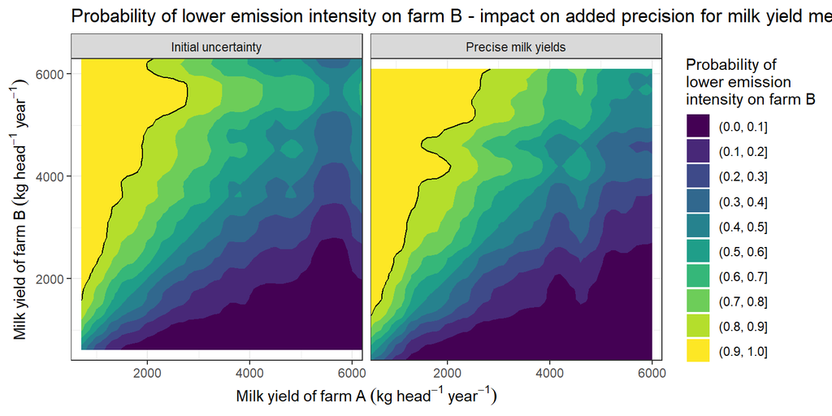

*Figure S9.* *Probability of a particular farm B featuring lower emission intensity of milk production than another farm A, based on observed per-head milk production levels, under the assumption that errors in milk yield estimates have been reduced to 15%. Estimates are derived from pairwise comparisons of slices through a population-wide generalization surface of the relationship between per-head milk production and emission intensity. This generalization was generated through Monte Carlo simulation, based on scenarios representing observed production settings on 414 livestock-keeping smallholder farms in Kenya.*

```r
dairy_households_update<-GHG_sim_update
dairy_households_update$x<-dairy_households_update$x[normal_milk_yield,]
dairy_households_update$y<-dairy_households_update$y[normal_milk_yield,]


milk_yields_to_sample<-seq(100,10000,100)
milk_yields_to_sample<-milk_yields_to_sample[which(milk_yields_to_sample<max(dairy_households_update$y$pc_milk_yield))]
milk_yields_to_sample<-milk_yields_to_sample[which(milk_yields_to_sample>min(dairy_households_update$y$pc_milk_yield))]
slices<-list()

# slice through the distribution at every 100 L milk yield per cow

for(i in 1:length(milk_yields_to_sample))
{slices[[i]]<-
  varslice_resample(dairy_households_update$y$pc_milk_yield,
                      dairy_households_update$y$CO2eq_per_milk,
                      expectedin_var = milk_yields_to_sample[i],
                      n_samples = 100000,
  out_var_sampling = 1000)$resample
 }

decreased_emissions_probability_update <-
  data.frame(Base_yield = NA,new_yield=NA,probability=NA)

for (i in 2:(length(milk_yields_to_sample) - 1))
{
  for (j in 1:length(milk_yields_to_sample))
    {decreased_emissions_probability_update[nrow(decreased_emissions_probability_update)+1,"Base_yield"]<-milk_yields_to_sample[i]
     decreased_emissions_probability_update$new_yield[nrow(decreased_emissions_probability_update)]<-milk_yields_to_sample[j]
     decreased_emissions_probability_update$probability[nrow(decreased_emissions_probability_update)] <-
      sum(slices[[i]] > slices[[j]]) / length(slices[[i]])
     decreased_emissions_probability_update$probability[nrow(decreased_emissions_probability_update)] <-
      sum(slices[[i]] > sample(slices[[j]], length(slices[[i]]))) / length(slices[[i]])

}
}

decreased_emissions_probability_update<-decreased_emissions_probability_update[which(!is.na(decreased_emissions_probability_update$Base_yield)),]

decreased_emissions_probability_update[,"version"]<-"Precise milk yields"
decreased_emissions_probability[,"version"]<-"Initial uncertainty"

dec_emiss_update_effects<-rbind(decreased_emissions_probability[,c("Base_yield","new_yield","probability","version")],
                                decreased_emissions_probability_update)

dec_emis_prob_update<-ggplot(data = dec_emiss_update_effects, aes(Base_yield, new_yield, z =
                                                      probability)) + geom_contour_filled() +
  ggtitle("Probability of lower emission intensity on farm B - impact on added precision for milk yield measurements") +
  labs(y=expression(Milk~yield~of~farm~B~(kg~head^{-1}~year^{-1})),
       x=expression(Milk~yield~of~farm~A~(kg~head^{-1}~year^{-1})),
       fill="Probability of \nlower emission \nintensity on farm B") +
  stat_contour(breaks = c(0.9),col="black") + theme_bw() + facet_wrap(~version) +
  scale_x_continuous(limits=c(min(dec_emiss_update_effects$Base_yield),max(dec_emiss_update_effects$Base_yield)),expand = c(0, 0)) +
  scale_y_continuous(limits=c(min(dec_emiss_update_effects$new_yield),max(dec_emiss_update_effects$new_yield)),expand = c(0, 0))

dec_emis_prob_update
```

```r
ggsave("figures/Fig_S9_updated_probability_of_lower_emission_intensity.png", width=10,height=5)
```

We need to implement the same interventions as for the initial simulation.

```r
## Produce endline breed scenario
x_breed_intervention_update_endline <- GHG_sim_update_endline$x

for (i in breed_adopters)
{x_breed_intervention_update_endline[i, colnames(breed_intervention)[2:ncol(breed_intervention)]] <-
 x_breed_intervention_update_endline[i, colnames(breed_intervention)[2:ncol(breed_intervention)]] *
    breed_intervention[which(paste0("Farm_", breed_intervention$Farm) ==
                               x_breed_intervention_update_endline$Scenario[i]),
                       2:ncol(breed_intervention)]
}

## Herd intervention 1 - nobulls

x_nobull_intervention_update_endline <- GHG_sim_update_endline$x
x_nobull_intervention_update_endline$N_animal_type_1[nobull_adopters]<-0

## Herd intervention 2 - lessReplace

x_lessReplace_intervention_update_endline <- GHG_sim_update_endline$x
x_lessReplace_intervention_update_endline$N_animal_type_3[lessReplace_adopters]<-0

## Feed intervention 1 - Supplementary legume fodder

x_Calliandra_intervention_update_endline <- GHG_sim_update_endline$x
for (i in Calliandra_adopters)
{x_Calliandra_intervention_update_endline$milk_yield_5[i]<-x_Calliandra_intervention_update_endline$milk_yield_5[i]+0.156
 x_Calliandra_intervention_update_endline$milk_yield_6[i]<-x_Calliandra_intervention_update_endline$milk_yield_6[i]+0.156
 x_Calliandra_intervention_update_endline$DE_perc[i]<-x_Calliandra_intervention_update_endline$DE_perc[i]+0.14
 x_Calliandra_intervention_update_endline$perc_crude_protein_diet[i]<-x_Calliandra_intervention_update_endline$perc_crude_protein_diet[i]-0.07
 x_Calliandra_intervention_update_endline$feed_prod_CO2[i]<-x_Calliandra_intervention_update_endline$feed_prod_CO2[i]- (0.726 *
                                        sum(x_Calliandra_intervention_update_endline[i,paste0("N_animal_type_",1:12)]))
}


## Feed intervention 2 - Balanced diets

x_balance_intervention_update_endline <- GHG_sim_update_endline$x
for (i in balance_adopters)
{x_balance_intervention_update_endline$milk_yield_5[i]<-x_balance_intervention_update_endline$milk_yield_5[i]+0.75
 x_balance_intervention_update_endline$milk_yield_6[i]<-x_balance_intervention_update_endline$milk_yield_6[i]+0.75
 x_balance_intervention_update_endline$feed_prod_CO2[i]<-x_balance_intervention_update_endline$feed_prod_CO2[i]-(328.5 *
                    sum(x_balance_intervention_update_endline[i,paste0("N_animal_type_",1:12)]))
}
```

```r
# run model for modified x file (endline)
breed_end_update <- run_model(x_breed_intervention_update_endline, ghg_emissions)
nobull_end_update <- run_model(x_nobull_intervention_update_endline, ghg_emissions)
lessReplace_end_update <- run_model(x_lessReplace_intervention_update_endline, ghg_emissions)
Calliandra_end_update <- run_model(x_Calliandra_intervention_update_endline, ghg_emissions)
balance_end_update <- run_model(x_balance_intervention_update_endline, ghg_emissions)

breed_end_update$y[,"CO2eq_per_milk"]<-breed_end_update$y$pc_on_farm/breed_end_update$y$pc_milk_yield
nobull_end_update$y[,"CO2eq_per_milk"]<-nobull_end_update$y$pc_on_farm/nobull_end_update$y$pc_milk_yield
lessReplace_end_update$y[,"CO2eq_per_milk"]<-lessReplace_end_update$y$pc_on_farm/lessReplace_end_update$y$pc_milk_yield
Calliandra_end_update$y[,"CO2eq_per_milk"]<-Calliandra_end_update$y$pc_on_farm/Calliandra_end_update$y$pc_milk_yield
balance_end_update$y[,"CO2eq_per_milk"]<-balance_end_update$y$pc_on_farm/balance_end_update$y$pc_milk_yield

breed_end_update$call<-"multi-scenario call"
save_temperature_scenarios(breed_end_update,"results","End_update_Breed_intervention")
nobull_end_update$call<-"multi-scenario call"
save_temperature_scenarios(nobull_end_update,"results","End_update_Nobull_intervention")
lessReplace_end_update$call<-"multi-scenario call"
save_temperature_scenarios(lessReplace_end_update,"results","End_update_LessReplace_intervention")
Calliandra_end_update$call<-"multi-scenario call"
save_temperature_scenarios(Calliandra_end_update,"results","End_update_Calliandra_intervention")
balance_end_update$call<-"multi-scenario call"
save_temperature_scenarios(balance_end_update,"results","End_update_Balance_intervention")
```

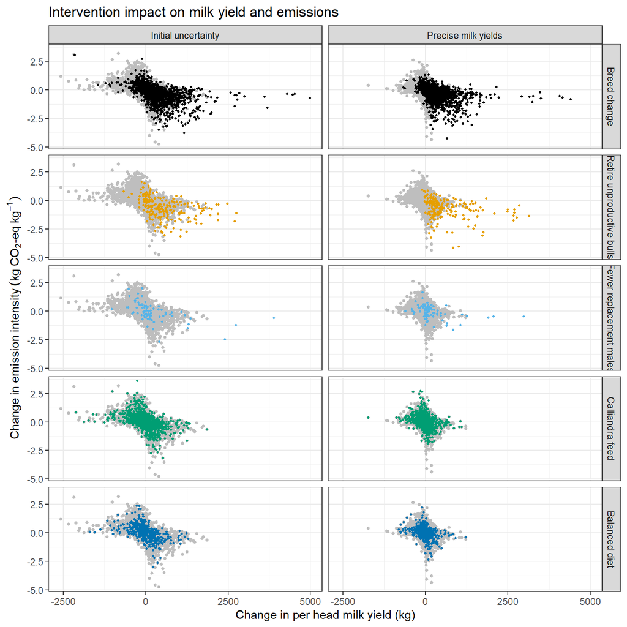

*Figure S10.* *Intervention impacts on milk production per head and greenhouse gas emission intensity, in comparison to random changes between two evaluation times. The gray dots illustrate random changes that occurred on farms that made no management changes, whereas the colored dots show changes on farms that implemented the respective interventions.*

```r
# make data.frame with all intervention results

interventions_end_update<-rbind(cbind(breed_end_update$y[breed_adopters,],
                           intervention="breed",
                           pc_milk_baseline=GHG_sim_update$y$pc_milk_yield[breed_adopters],
                           CO2_intensity_baseline=GHG_sim_update$y$CO2eq_per_milk[breed_adopters]),
                     cbind(nobull_end_update$y[nobull_adopters,],
                           intervention="nobull",
                           pc_milk_baseline=GHG_sim_update$y$pc_milk_yield[nobull_adopters],
                           CO2_intensity_baseline=GHG_sim_update$y$CO2eq_per_milk[nobull_adopters]),
                     cbind(lessReplace_end_update$y[lessReplace_adopters,],
                           intervention="lessReplace",
                           pc_milk_baseline=GHG_sim_update$y$pc_milk_yield[lessReplace_adopters],
                           CO2_intensity_baseline=GHG_sim_update$y$CO2eq_per_milk[lessReplace_adopters]),
                     cbind(Calliandra_end_update$y[Calliandra_adopters,],
                           intervention="Calliandra",
                           pc_milk_baseline=GHG_sim_update$y$pc_milk_yield[Calliandra_adopters],
                           CO2_intensity_baseline=GHG_sim_update$y$CO2eq_per_milk[Calliandra_adopters]),
                     cbind(balance_end_update$y[balance_adopters,],
                           intervention="balance",
                           pc_milk_baseline=GHG_sim_update$y$pc_milk_yield[balance_adopters],
                           CO2_intensity_baseline=GHG_sim_update$y$CO2eq_per_milk[balance_adopters]))

normal_end_update<-cbind(GHG_sim_update_endline$y,
                           pc_milk_baseline=GHG_sim_update$y$pc_milk_yield,
                           CO2_intensity_baseline=GHG_sim_update$y$CO2eq_per_milk)
normal_end_update[,"CO2eq_per_milk"]<-normal_end_update$pc_on_farm/normal_end_update$pc_milk_yield


interventions_end_update[,"milk_change"]<-interventions_end_update$pc_milk_yield-interventions_end_update$pc_milk_baseline
interventions_end_update[,"emission_intensity_change"]<-interventions_end_update$CO2eq_per_milk-interventions_end_update$CO2_intensity_baseline
interventions_end_update[,"milk_change_relative"]<-(interventions_end_update$pc_milk_yield-interventions_end_update$pc_milk_baseline)/interventions_end_update$pc_milk_baseline*100
interventions_end_update[,"emission_intensity_change_relative"]<-
  (interventions_end_update$CO2eq_per_milk-interventions_end_update$CO2_intensity_baseline)/interventions_end_update$CO2_intensity_baseline*100

normal_end_update[,"milk_change"]<-normal_end_update$pc_milk_yield-normal_end_update$pc_milk_baseline
normal_end_update[,"emission_intensity_change"]<-normal_end_update$CO2eq_per_milk-normal_end_update$CO2_intensity_baseline
normal_end_update[,"milk_change_relative"]<-(normal_end_update$pc_milk_yield-normal_end_update$pc_milk_baseline)/normal_end_update$pc_milk_baseline*100
normal_end_update[,"emission_intensity_change_relative"]<-
  (normal_end_update$CO2eq_per_milk-normal_end_update$CO2_intensity_baseline)/normal_end_update$CO2_intensity_baseline*100




interventions_normal_milk_end_update<-interventions_end_update[which(interventions_end_update$pc_milk_baseline>500),]
normal_normal_milk_end_update<-normal_end_update[which(normal_end_update$pc_milk_yield>500),]
normal_plot_update<-rbind(cbind(normal_normal_milk_end_update,intervention="breed"),
                   cbind(normal_normal_milk_end_update,intervention="nobull"),
                   cbind(normal_normal_milk_end_update,intervention="lessReplace"),
                   cbind(normal_normal_milk_end_update,intervention="Calliandra"),
                   cbind(normal_normal_milk_end_update,intervention="balance"))

intervention_colors<-palette.colors(n = 6, palette = "Okabe-Ito", alpha=1, recycle = FALSE)

normal_plot_update[,"version"]<-"Precise milk yields"
normal_plot[,"version"]<-"Initial uncertainty"

normal_stuff<-rbind(normal_plot,normal_plot_update)

interventions_normal_milk_end_update[,"version"]<-"Precise milk yields"
interventions_normal_milk_end[,"version"]<-"Initial uncertainty"

interventions_normal_stuff<-rbind(interventions_normal_milk_end,interventions_normal_milk_end_update)


interventions_scatter_end_update<-ggplot(data=normal_stuff,
                        aes(x=milk_change,y=emission_intensity_change)) +
  geom_point(color="gray",size=1) +
  geom_point(data=interventions_normal_stuff,
                        aes(x=milk_change,y=emission_intensity_change, color=intervention),size=0.8) +
  scale_color_manual(values= c("breed" = intervention_colors[1],
                              "nobull" = intervention_colors[2],
                              "lessReplace" = intervention_colors[3],
                              "Calliandra" = intervention_colors[4],
                              "balance" = intervention_colors[6]),
                    labels = c("Breed change", "No bulls", "Fewer males", "Calliandra feed", "Balanced diet")) +
  theme_bw() +
  ggtitle("Intervention impact on milk yield and emissions") +
  labs(y=expression(Change~'in'~emission~intensity~(kg~CO[2]*'-eq'~kg^-1)),
       x="Change in per head milk yield (kg)",
       color="Intervention")  +
  facet_grid(cols=vars(version),
             rows=vars(factor(intervention,
                     levels=c("breed","nobull","lessReplace","Calliandra","balance"),
                     labels=c("Breed change", "Retire unproductive bulls", "Fewer replacement males", "Calliandra feed", "Balanced diet")))) +
  theme(legend.position = "none")

interventions_scatter_end_update
```

```r
ggsave("figures/Fig_S10_intervention_impacts_endline.png", width=9,height=12)
```

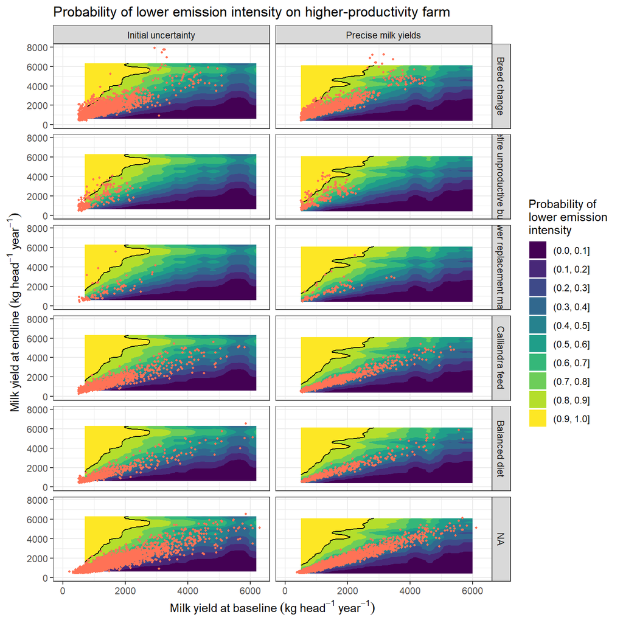

*Figure S11.* *Intervention impacts on milk yield and greenhouse gas emission intensity at an endline sampling point vs. the initial sampling time, comparing initial uncertainty with improved measurements of milk yields (assuming a reduction of measurement errors to 15%). The colored background surface indicates the probability that increases in milk productivity are associated with decreasing emission intensity.*

```r
interventions_plot_update<-interventions_normal_milk_end_update
none_plot_update<-cbind(normal_normal_milk_end_update ,intervention="none", version="Precise milk yields")

int_none_plot_update<-rbind(interventions_plot_update,none_plot_update)

decreased_emissions_probability_update[,"version"]<-"Precise milk yields"
decreased_emissions_probability[,"version"]<-"Initial uncertainty"
decreased_emissions_probability_stuff<-rbind(decreased_emissions_probability[,c("Base_yield","new_yield","probability","version")],
                                             decreased_emissions_probability_update)

int_none_plot_update[,"version"]<-"Precise milk yields"
int_none_plot[,"version"]<-"Initial uncertainty"
int_none_plot_stuff<-rbind(int_none_plot[,which(!colnames(int_none_plot)=="confidence_level")],int_none_plot_update)




interventions_probability_update<-ggplot(data = decreased_emissions_probability_stuff, aes(Base_yield, new_yield)) +
  geom_contour_filled(aes(z=probability)) +
  ggtitle("Probability of lower emission intensity on higher-productivity farm") +
  labs(y=expression(Milk~yield~at~endline~(kg~head^{-1}~year^{-1})),
       x=expression(Milk~yield~at~baseline~(kg~head^{-1}~year^{-1})),
       fill="Probability of \nlower emission \nintensity") +
  stat_contour(aes(z=probability),breaks = c(0.9),col="black") + theme_bw() +
  geom_point(data=int_none_plot_stuff,aes(x=pc_milk_baseline,y=pc_milk_yield), size=0.8, color="coral1") +
  ylim(c(0,NA)) + xlim(c(0,NA)) +
  facet_grid(cols=vars(version),
             rows=vars(factor(intervention,
                     levels=c("breed","nobull","lessReplace","Calliandra","balance"),
                     labels=c("Breed change", "Retire unproductive bulls", "Fewer replacement males", "Calliandra feed", "Balanced diet"))))

interventions_probability_update
```

```r
ggsave("figures/Fig_S11_probability_of_lower_emission_intensity_interventions.png", width=7,height=12)
```

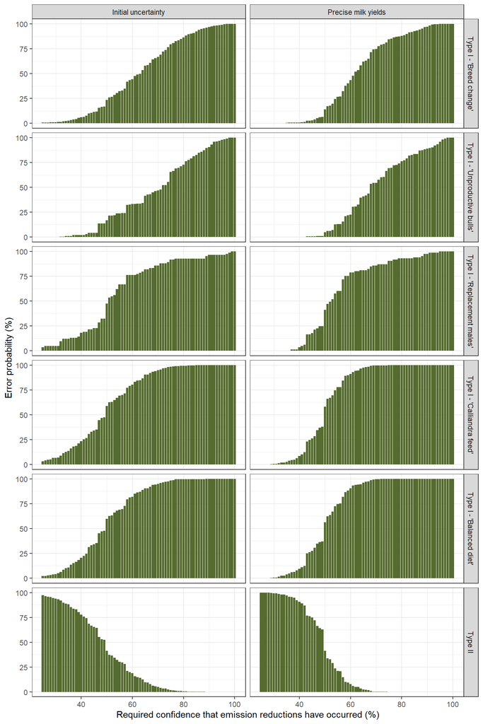

*Figure S12.* *Probability of Type I and Type II errors incurred by choosing specific levels of confidence that emission intensity changes have actually occurred, comparing initial uncertainty with improved measurements of milk yields (assuming a reduction of measurement errors to 15%). Type I errors indicate the probability of failing to recognize households that implemented interventions, whereas the Type II error represents the percentage of households that did not make any changes, but are nevertheless rewarded due to random effects.*

```r
# get closest probability value

for(i in 1:nrow(int_none_plot_update))
  {decreased_emissions_probability_update[,"diff"]<-
    abs(decreased_emissions_probability_update$Base_yield-int_none_plot_update$pc_milk_baseline [i]) +
    abs(decreased_emissions_probability_update$new_yield-int_none_plot_update$pc_milk_yield[i])
  int_none_plot_update[i,"confidence_level"]<-decreased_emissions_probability_update$probability[which(decreased_emissions_probability_update$diff==min(decreased_emissions_probability_update$diff))][1]
}

confidence_level_analysis_update<-data.frame(confidence=seq(0.25,1,0.01))

for(i in 1:nrow(confidence_level_analysis_update))
{# compute Type 1 errors for all interventions
  for(ints in c("breed", "nobull", "lessReplace", "Calliandra", "balance"))
    confidence_level_analysis_update[i,ints]<-
      length(which(int_none_plot_update$intervention==ints &
                     int_none_plot_update$confidence_level <
                     confidence_level_analysis_update$confidence[i])) /
      length(which(int_none_plot_update$intervention==ints)) * 100

  confidence_level_analysis_update$Type2error[i]<-
    length(which(int_none_plot_update$intervention=="none" &
                   int_none_plot_update$confidence_level>confidence_level_analysis_update$confidence[i])) /
    length(which(int_none_plot_update$intervention=="none")) * 100

}

confidence_level_analysis_update$confidence<-confidence_level_analysis_update$confidence*100
confidence_plot_update<-melt(confidence_level_analysis_update,id.vars = "confidence")
confidence_plot_update$variable <- factor(confidence_plot_update$variable, levels = c("breed", "nobull", "lessReplace", "Calliandra", "balance", "Type2error"),
                  labels = c("Type I error - failure to reward 'Breed change' adopters",
                             "Type I error - failure to reward 'Retire unproductive bulls' adopters",
                             "Type I error - failure to reward 'Fewer replacement males' adopters",
                             "Type I error - failure to reward 'Calliandra feed' adopters",
                             "Type I error - failure to reward 'Balanced diet' adopters",
                             "Type II error - rewarding non-adopters"))


confidence_plot_update[,"version"]<-"Precise milk yields"
confidence_plot[,"version"]<-"Initial uncertainty"
confidence_plot_stuff<-rbind(confidence_plot,confidence_plot_update)
confidence_plot_stuff$variable <- factor(confidence_plot_stuff$variable,
                                         levels = c("Type I error - failure to reward 'Breed change' adopters",
                             "Type I error - failure to reward 'Retire unproductive bulls' adopters",
                             "Type I error - failure to reward 'Fewer replacement males' adopters",
                             "Type I error - failure to reward 'Calliandra feed' adopters",
                             "Type I error - failure to reward 'Balanced diet' adopters",
                             "Type II error - rewarding non-adopters"),
                  labels = c("Type I - 'Breed change'",
                             "Type I - 'Unproductive bulls'",
                             "Type I - 'Replacement males'",
                             "Type I - 'Calliandra feed'",
                             "Type I - 'Balanced diet'",
                             "Type II"))


ggplot(confidence_plot_stuff, aes(x=confidence,y=value)) + geom_bar(stat="identity", fill="darkolivegreen") + theme_bw() +
  labs(y="Error probability (%)", x="Required confidence that emission reductions have occurred (%)")+
  facet_grid(cols=vars(version),
             rows=vars(variable))
```

```r
ggsave("figures/Fig_S12_erorr_types.png", width=7,height=12)
```

Comparing the errors is easier in a line plot.

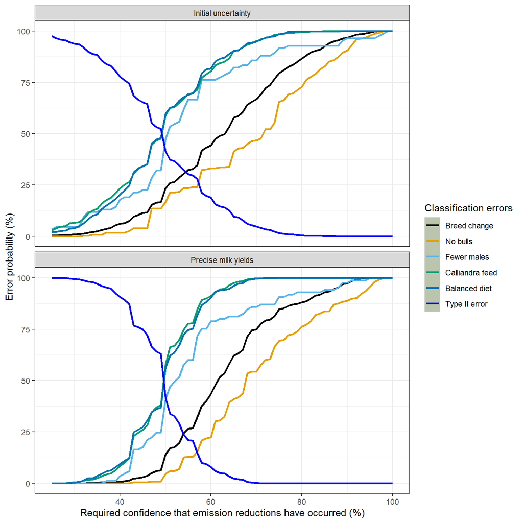

*Figure 11.* *Probability of Type I and Type II errors incurred by choosing specific levels of confidence that emission intensity changes have actually occurred, comparing initial uncertainty with improved measurements of milk yields (assuming a reduction of measurement errors to 15%). Type I errors indicate the probability of failing to recognize households that implemented interventions, whereas the Type II error represents the percentage of households that did not make any changes, but are nevertheless rewarded due to random effects.*

```r
ggplot(confidence_plot_stuff, aes(x=confidence,y=value, color=variable)) + geom_smooth(stat="identity", fill="darkolivegreen") +
  labs(y="Error probability (%)", x="Required confidence that emission reductions have occurred (%)",
       color="Classification errors") +
  facet_wrap(~version,nrow=2) +
  scale_color_manual(values= c("Type I - 'Breed change'" = intervention_colors[1],
                              "Type I - 'Unproductive bulls'" = intervention_colors[2],
                              "Type I - 'Replacement males'" = intervention_colors[3],
                              "Type I - 'Calliandra feed'" = intervention_colors[4],
                              "Type I - 'Balanced diet'" = intervention_colors[6],
                              "Type II" = "blue"),
                    labels = c("Breed change", "No bulls", "Fewer males", "Calliandra feed", "Balanced diet", "Type II error")) + theme_bw()
```

```r
ggsave("figures/Fig_11_erorr_types.png", width=7,height=7)
```

new sensitivity analysis

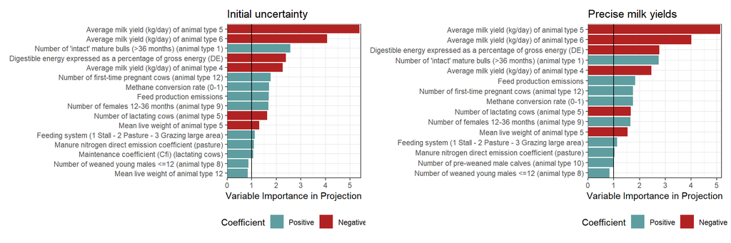

```r
pls_GHG<-dairy_households
pls_GHG$x<-pls_GHG$x[,which(!colnames(pls_GHG$x)=="Scenario")]
pls_out<-plsr.mcSimulation(object=pls_GHG, resultName = "CO2eq_per_milk")
legend_table<-read.csv("data/legend.csv", fileEncoding = "UTF-8-BOM")
PLS_initial<-plot_pls(pls_out,input_table=legend_table) + ggtitle("Initial uncertainty")

pls_GHG_update<-dairy_households_update
pls_GHG_update$x<-pls_GHG_update$x[,which(!colnames(pls_GHG_update$x)=="Scenario")]
pls_out_update<-plsr.mcSimulation(object=pls_GHG_update, resultName = "CO2eq_per_milk")

PLS_update<-plot_pls(pls_out_update,input_table=legend_table) + ggtitle("Precise milk yields")

PLS_initial + PLS_update
```

```r
ggsave("figures/Fig_S13_PLS_dairy_households_update.png", width=12,height=4)
```

# References

Dong, Hongmin, James Douglas MacDonald, Stephen Michael Ogle, Maria José Sanz Sanchez, and Marcelo Theoto Rocha. 2019. “Volume 4 - Agriculture, Forestry and Other Land Use.” In *IPCC Refinement to the 2006 IPCC Guidelines for National Greenhouse Gas Inventories*, edited by E. Calvo Buendia, K. Tanabe, A. Baasansuren, M. Fukuda, S. Ngarize, A. Osako, Y. Pyrozhenko, P. Shermanau, and S. Federici. Switzerland: The Intergovernmental Panel on Climate Change. https://www.ipcc-nggip.iges.or.jp/public/2019rf/pdf/4_Volume4/19R_V4_Cover.pdf.

Dong, Hongmin, Joe Mangino, Tim McAllister, Jerry Hatfield, Donald Johnson, Keith Lassey, Magda Aparecida de Lima, and Anna Romanovskaya. 2006. *IPCC Guidelines for National Greenhouse Gas Inventories - Volume 4 Agriculture, Forestry and Other Land Use*. https://www.ipcc-nggip.iges.or.jp/public/2006gl/pdf/4_Volume4/V4_10_Ch10_Livestock.pdf.

IPCC. 2021. *Good Practice Guidance and Uncertainty Management in National Greenhouse Gas Inventories*. Intergovernmental Panel on Climate Change (IPCC). https://www.ipcc-nggip.iges.or.jp/public/gp/english/.

Luedeling, Eike, Lutz Goehring, Katja Schiffers, Cory Whitney, and Eduardo Fernandez. 2022. *decisionSupport: Quantitative Support of Decision Making Under Uncertainty*. http://www.worldagroforestry.org/.

R Core Team. 2021. *R: A Language and Environment for Statistical Computing*. Vienna, Austria: R Foundation for Statistical Computing. https://www.R-project.org/.

Wilkes, Andreas, Charles Odhong, Suzanne van Dijk, Simon Fraval, and Shimels Eshete Wassie. 2019. “Methods and Guidance to Support MRV of Livestock Emissions (Working Paper No. 285).” CGIAR Research Program on Climate Change, Agriculture; Food Security (CCAFS).

Wilkes, Andreas, Shimels Wassie, Charles Odhong’, Simon Fraval, and Suzanne van Dijk. 2020. “Variation in the Carbon Footprint of Milk Production on Smallholder Dairy Farms in Central Kenya.” *Journal of Cleaner Production* 265 (August): 121780. https://doi.org/10.1016/j.jclepro.2020.121780.